# Trade&Ahead

**Description**

*Context*

The stock market has consistently proven to be a good place to invest in and save for the future. There are a lot of compelling reasons to invest in stocks. It can help in fighting inflation, create wealth, and also provides some tax benefits. Good steady returns on investments over a long period of time can also grow a lot more than seems possible. Also, thanks to the power of compound interest, the earlier one starts investing, the larger the corpus one can have for retirement. Overall, investing in stocks can help meet life's financial aspirations.

It is important to maintain a diversified portfolio when investing in stocks to maximize earnings under any market condition. Having a diversified portfolio tends to yield higher returns and face lower risk by tempering potential losses when the market is down. It is often easy to get lost in a sea of financial metrics to analyze while determining the worth of a stock, and doing the same for a multitude of stocks to identify the right picks for an individual can be a tedious task. By doing a cluster analysis, one can identify stocks that exhibit similar characteristics and ones that exhibit minimum correlation. This will help investors better analyze stocks across different market segments and help protect against risks that could make the portfolio vulnerable to losses.

*Objective*

Trade&Ahead is a financial consultancy firm that provides its customers with personalized investment strategies. They have hired you as a Data Scientist and provided you with data comprising stock price and some financial indicators for a few companies listed under the New York Stock Exchange. They have assigned you the tasks of analyzing the data, grouping the stocks based on the attributes provided, and sharing insights about the characteristics of each group.

**Data Description**

The data provided is of stock prices and some financial indicators like ROE, earnings per share, P/E ratio, etc.

Data Dictionary

Ticker Symbol: An abbreviation used to uniquely identify publicly traded shares of a particular stock on a particular stock market

Company: Name of the company

GICS Sector: The specific economic sector assigned to a company by the Global Industry Classification Standard (GICS) that best defines its business operations

GICS Sub Industry: The specific sub-industry group assigned to a company by the Global Industry Classification Standard (GICS) that best defines its business operations

Current Price: Current stock price in dollars

Price Change: Percentage change in the stock price in 13 weeks

Volatility: Standard deviation of the stock price over the past 13 weeks

ROE: A measure of financial performance calculated by dividing net income by shareholders' equity (shareholders' equity is equal to a company's assets minus its debt)

Cash Ratio: The ratio of a company's total reserves of cash and cash equivalents to its total current liabilities

Net Cash Flow: The difference between a company's cash inflows and outflows (in dollars)

Net Income: Revenues minus expenses, interest, and taxes (in dollars)

Earnings Per Share: Company's net profit divided by the number of common shares it has outstanding (in dollars)

Estimated Shares Outstanding: Company's stock is currently held by all its shareholders

P/E Ratio: Ratio of the company's current stock price to the earnings per share

P/B Ratio: Ratio of the company's stock price per share by its book value per share (book value of a company is the net difference between that company's total assets and total liabilities)

```python
from google.colab import files


uploaded = files.upload()
```

Upload widget is only available when the cell has been executed in the current browser session. Please rerun this cell to enable.

```
Saving stock_data.csv to stock_data.csv
```

```python
import numpy as np
import pandas as pd

# import libraries for data visualization
import matplotlib.pyplot as plt
import seaborn as sns
```

```python
import io

df = pd.read_csv(io.BytesIO(uploaded['stock_data.csv']))
print(df)
```

```
    Ticker Symbol                 Security             GICS Sector  \
0             AAL  American Airlines Group             Industrials
1            ABBV                   AbbVie             Health Care
2             ABT      Abbott Laboratories             Health Care
3            ADBE        Adobe Systems Inc  Information Technology
4             ADI     Analog Devices, Inc.  Information Technology
..            ...                      ...                     ...
335          YHOO               Yahoo Inc.  Information Technology
336           YUM          Yum! Brands Inc  Consumer Discretionary
337           ZBH   Zimmer Biomet Holdings             Health Care
338          ZION            Zions Bancorp              Financials
339           ZTS                   Zoetis             Health Care

                GICS Sub Industry  Current Price  Price Change  Volatility  \
0                        Airlines      42.349998      9.999995    1.687151
```

[output cut: 38 more lines]

Observations:

The DataFrame has 340 rows and 15 columns as mentioned in the Data Dictionary.

```python
df.head()
```

|  | Ticker Symbol | Security | GICS Sector | GICS Sub Industry | Current Price | Price Change | Volatility | ROE | Cash Ratio | Net Cash Flow | Net Income | Earnings Per Share | Estimated Shares Outstanding | P/E Ratio | P/B Ratio |
| --- | --- | --- | --- | --- | --- | --- | --- | --- | --- | --- | --- | --- | --- | --- | --- |
| 0 | AAL | American Airlines Group | Industrials | Airlines | 42.349998 | 9.999995 | 1.687151 | 135 | 51 | -604000000 | 7610000000 | 11.39 | 6.681299e+08 | 3.718174 | -8.784219 |
| 1 | ABBV | AbbVie | Health Care | Pharmaceuticals | 59.240002 | 8.339433 | 2.197887 | 130 | 77 | 51000000 | 5144000000 | 3.15 | 1.633016e+09 | 18.806350 | -8.750068 |
| 2 | ABT | Abbott Laboratories | Health Care | Health Care Equipment | 44.910000 | 11.301121 | 1.273646 | 21 | 67 | 938000000 | 4423000000 | 2.94 | 1.504422e+09 | 15.275510 | -0.394171 |
| 3 | ADBE | Adobe Systems Inc | Information Technology | Application Software | 93.940002 | 13.977195 | 1.357679 | 9 | 180 | -240840000 | 629551000 | 1.26 | 4.996437e+08 | 74.555557 | 4.199651 |
| 4 | ADI | Analog Devices, Inc. | Information Technology | Semiconductors | 55.320000 | -1.827858 | 1.701169 | 14 | 272 | 315120000 | 696878000 | 0.31 | 2.247994e+09 | 178.451613 | 1.059810 |

```python
df.info()
```

```
<class 'pandas.core.frame.DataFrame'>
RangeIndex: 340 entries, 0 to 339
Data columns (total 15 columns):
 #   Column                        Non-Null Count  Dtype
---  ------                        --------------  -----
 0   Ticker Symbol                 340 non-null    object
 1   Security                      340 non-null    object
 2   GICS Sector                   340 non-null    object
 3   GICS Sub Industry             340 non-null    object
 4   Current Price                 340 non-null    float64
 5   Price Change                  340 non-null    float64
 6   Volatility                    340 non-null    float64
 7   ROE                           340 non-null    int64
 8   Cash Ratio                    340 non-null    int64
 9   Net Cash Flow                 340 non-null    int64
 10  Net Income                    340 non-null    int64
 11  Earnings Per Share            340 non-null    float64
 12  Estimated Shares Outstanding  340 non-null    float64
 13  P/E Ratio                     340 non-null    float64
 14  P/B Ratio                     340 non-null    float64
dtypes: float64(7), int64(4), object(4)
memory usage: 40.0+ KB
```

```python
df.shape
```

```
(340, 15)
```

```python
missing_values=pd.isnull(df)
print(missing_values)
```

```
     Ticker Symbol  Security  GICS Sector  GICS Sub Industry  Current Price  \
0            False     False        False              False          False
1            False     False        False              False          False
2            False     False        False              False          False
3            False     False        False              False          False
4            False     False        False              False          False
..             ...       ...          ...                ...            ...
335          False     False        False              False          False
336          False     False        False              False          False
337          False     False        False              False          False
338          False     False        False              False          False
339          False     False        False              False          False

     Price Change  Volatility    ROE  Cash Ratio  Net Cash Flow  Net Income  \
0           False       False  False       False          False       False
```

[output cut: 25 more lines]

```python
df.isnull().sum()
```

|  | 0 |
| --- | --- |
| Ticker Symbol | 0 |
| Security | 0 |
| GICS Sector | 0 |
| GICS Sub Industry | 0 |
| Current Price | 0 |
| Price Change | 0 |
| Volatility | 0 |
| ROE | 0 |
| Cash Ratio | 0 |
| Net Cash Flow | 0 |
| Net Income | 0 |
| Earnings Per Share | 0 |
| Estimated Shares Outstanding | 0 |
| P/E Ratio | 0 |
| P/B Ratio | 0 |

**dtype:** int64

**Observations**

It shows that there are no missing values across each columns.

Statistical Summary of Numeric variables

```python
summary = df.describe()
print(summary)
```

```
       Current Price  Price Change  Volatility         ROE  Cash Ratio  \
count     340.000000    340.000000  340.000000  340.000000  340.000000
mean       80.862345      4.078194    1.525976   39.597059   70.023529
std        98.055086     12.006338    0.591798   96.547538   90.421331
min         4.500000    -47.129693    0.733163    1.000000    0.000000
25%        38.555000     -0.939484    1.134878    9.750000   18.000000
50%        59.705000      4.819505    1.385593   15.000000   47.000000
75%        92.880001     10.695493    1.695549   27.000000   99.000000
max      1274.949951     55.051683    4.580042  917.000000  958.000000

       Net Cash Flow    Net Income  Earnings Per Share  \
count   3.400000e+02  3.400000e+02          340.000000
mean    5.553762e+07  1.494385e+09            2.776662
std     1.946365e+09  3.940150e+09            6.587779
min    -1.120800e+10 -2.352800e+10          -61.200000
25%    -1.939065e+08  3.523012e+08            1.557500
50%     2.098000e+06  7.073360e+08            2.895000
75%     1.698108e+08  1.899000e+09            4.620000
max     2.076400e+10  2.444200e+10           50.090000

       Estimated Shares Outstanding   P/E Ratio   P/B Ratio
count                  3.400000e+02  340.000000  340.000000
mean                   5.770283e+08   32.612563   -1.718249
std                    8.458496e+08   44.348731   13.966912
min                    2.767216e+07    2.935451  -76.119077
25%                    1.588482e+08   15.044653   -4.352056
50%                    3.096751e+08   20.819876   -1.067170
75%                    5.731175e+08   31.764755    3.917066
max                    6.159292e+09  528.039074  129.064585
```

Observations

Current Price:

Mean: $80.86

Std Dev: $98.06 (high variability in stock prices).

Range: $4.50 to $1,274.95 (wide variation across stocks).

Price Change:

Mean: 4.08% (positive growth on average).

Std Dev: 12.01% (high volatility in stock price changes).

Range: -47.13% to 55.05% (some stocks experienced significant declines or gains).

Volatility:

Mean: 1.53 (moderate volatility overall).

Std Dev: 0.59 (some stocks show higher variability in their price changes).

Range: 0.73 to 4.58 (stocks with higher volatility may be more risky).

ROE (Return on Equity):

Mean: 39.60% (suggesting good profitability overall).

Std Dev: 96.55% (extreme variability in ROE, indicating large differences in profitability).

Range: 1% to 917% (some stocks have extremely high ROE, while others may be more modest).

Cash Ratio:

Mean: 70.02 (good liquidity across companies).

Std Dev: 90.42 (high variation in liquidity among companies).

Range: 0 to 958 (some companies hold significantly higher cash reserves).

Net Cash Flow:

Mean: $55.54 million **(positive cash flow on average)**.

Std Dev: $1.95 billion (very large spread in cash flow between companies).

Range: -$11.2 billion to $20.76 billion (some companies are highly cash flow negative, while others generate a significant surplus).

Net Income:

Mean: $1.49 billion.

Range: -$23.53 billion to $24.44 billion (some companies are losing money while others are highly profitable).

Earnings Per Share (EPS):

Mean: $2.78 (positive overall earnings).

Range: -$61.20 to $50.09 (a few companies have negative EPS, indicating losses).

P/E Ratio:

Mean: 32.61 (higher average valuation).

Std Dev: 44.35 (extreme variation in valuation multiples).

Range: 2.94 to 528.04 (some stocks are highly overvalued, while others are undervalued).

P/B Ratio:

Mean: -1.72 (average negative book value ratios).

Range: -76.12 to 129.06 (some stocks have negative equity, others have high book value).

**Statistical Summary of Categorical variables**

```python
df.describe(include = ['object']).T
```

|  | count | unique | top | freq |
| --- | --- | --- | --- | --- |
| Ticker Symbol | 340 | 340 | AAL | 1 |
| Security | 340 | 340 | American Airlines Group | 1 |
| GICS Sector | 340 | 11 | Industrials | 53 |
| GICS Sub Industry | 340 | 104 | Oil & Gas Exploration & Production | 16 |

Categorical Data Overview

Ticker Symbol:

Count: 340 unique ticker symbols (each company in the dataset is represented only once).

Security: Count: 340 unique companies (each company is distinct). Top Company: "American Airlines Group" is one of the companies listed (though this just happens to be the first entry).

GICS Sector: Count: 340 total stocks.

Unique Sectors: 11 sectors are represented, covering different parts of the economy.

Top Sector: "Industrials" with 53 companies (the largest sector in the dataset).

GICS Sub Industry: Count: 340 stocks across 104 sub-industries.

Top Sub-Industry: "Oil & Gas Exploration & Production" with 16 companies

**Check for duplicates**

```python
# Check for duplicates
duplicate_rows = df[df.duplicated()]

# Print the duplicate rows
print("Duplicate Rows:")
print(duplicate_rows)

# Optionally, you can also count the number of duplicates
num_duplicates = df.duplicated().sum()
print("Number of duplicates:", num_duplicates)
```

```
Duplicate Rows:
Empty DataFrame
Columns: [Ticker Symbol, Security, GICS Sector, GICS Sub Industry, Current Price, Price Change, Volatility, ROE, Cash Ratio, Net Cash Flow, Net Income, Earnings Per Share, Estimated Shares Outstanding, P/E Ratio, P/B Ratio]
Index: []
Number of duplicates: 0
```

**Exploratory Data Analysis (EDA)**

EDA is an important part of any project involving data. It is important to investigate and understand the data better before building a model with it. A few questions have been mentioned below which will help you approach the analysis in the right manner and generate insights from the data. A thorough analysis of the data, in addition to the questions mentioned below, should be done.

**Univariate Analysis for Numerical Variables**

```
       Current Price  Price Change  Volatility         ROE  Cash Ratio  \
count     340.000000    340.000000  340.000000  340.000000  340.000000
mean       80.862345      4.078194    1.525976   39.597059   70.023529
std        98.055086     12.006338    0.591798   96.547538   90.421331
min         4.500000    -47.129693    0.733163    1.000000    0.000000
25%        38.555000     -0.939484    1.134878    9.750000   18.000000
50%        59.705000      4.819505    1.385593   15.000000   47.000000
75%        92.880001     10.695493    1.695549   27.000000   99.000000
max      1274.949951     55.051683    4.580042  917.000000  958.000000

       Net Cash Flow    Net Income  Earnings Per Share   P/E Ratio   P/B Ratio
count   3.400000e+02  3.400000e+02          340.000000  340.000000  340.000000
mean    5.553762e+07  1.494385e+09            2.776662   32.612563   -1.718249
std     1.946365e+09  3.940150e+09            6.587779   44.348731   13.966912
min    -1.120800e+10 -2.352800e+10          -61.200000    2.935451  -76.119077
25%    -1.939065e+08  3.523012e+08            1.557500   15.044653   -4.352056
50%     2.098000e+06  7.073360e+08            2.895000   20.819876   -1.067170
75%     1.698108e+08  1.899000e+09            4.620000   31.764755    3.917066
max     2.076400e+10  2.444200e+10           50.090000  528.039074  129.064585
```

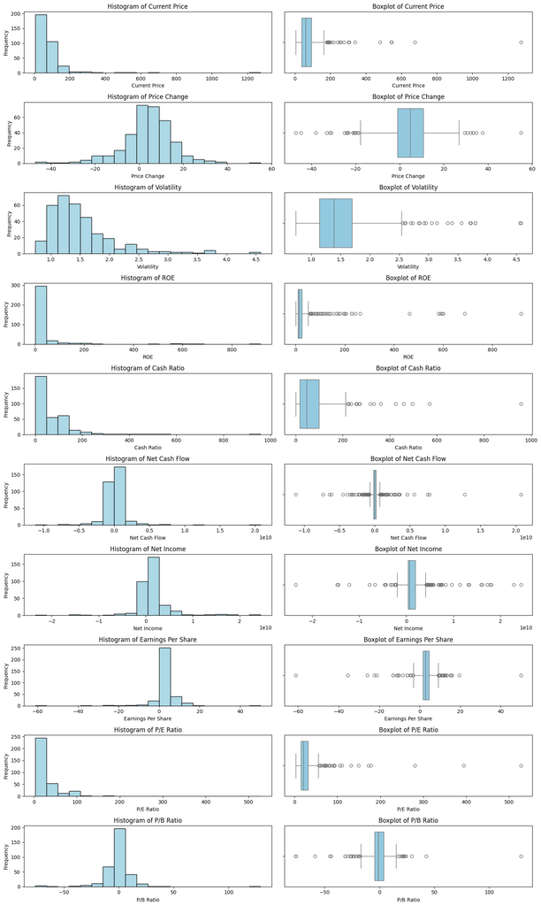

```python
import pandas as pd
import matplotlib.pyplot as plt
import seaborn as sns

# Load the dataset
data = pd.read_csv('stock_data.csv')

# List of numerical columns for univariate analysis
numerical_columns = ['Current Price', 'Price Change', 'Volatility', 'ROE', 'Cash Ratio',
                     'Net Cash Flow', 'Net Income', 'Earnings Per Share', 'P/E Ratio', 'P/B Ratio']

# Display summary statistics for each numerical column
print(data[numerical_columns].describe())

# Visualize the univariate analysis: Histograms for distribution and Box plots for outliers
plt.figure(figsize=(15, 25))

# Loop through numerical columns
for i, col in enumerate(numerical_columns):
    plt.subplot(len(numerical_columns), 2, 2 * i + 1)
    plt.hist(data[col], bins=20, edgecolor='black', color='lightblue')
    plt.title(f'Histogram of {col}')
    plt.xlabel(col)
    plt.ylabel('Frequency')

    plt.subplot(len(numerical_columns), 2, 2 * i + 2)
    sns.boxplot(x=data[col], color='skyblue')
    plt.title(f'Boxplot of {col}')
    plt.xlabel(col)

plt.tight_layout()
plt.show()
```

**Observations based on the histograms and box plots generated for the univariate analysis of the dataset:**

1. Current Price: Histogram: The current prices are highly skewed to the right. Most companies have stock prices below $200, with a few companies having prices extending as high as $1,200.

Box Plot: There are several outliers above $200, indicating that a few companies have significantly higher stock prices than the rest.

1. Price Change: Histogram: The price change follows a more normal distribution, centered around 0%. Most stocks have seen moderate changes, either positive or negative, over the past 13 weeks.

Box Plot: There are several outliers on both the negative and positive sides, suggesting that a few companies experienced extreme price movements during the period.

1. Volatility: Histogram: Volatility is slightly right-skewed, with most companies having moderate volatility around 1.5.

Box Plot: There are some outliers for volatility values above 3.0, indicating that a few stocks are significantly more volatile.

1. ROE (Return on Equity): Histogram: ROE is highly right-skewed. The majority of companies have an ROE below 50%, but there are some extreme values extending up to over 800%.

Box Plot: There are many outliers above 50%, suggesting that a few companies have extremely high profitability compared to others.

1. Cash Ratio: Histogram: The cash ratio is also right-skewed. Most companies have a cash ratio below 200%, but a few extend much higher.

Box Plot: There are many outliers, indicating that some companies hold significantly higher cash reserves relative to their current liabilities.

1. Net Cash Flow: Histogram: The distribution of net cash flow is concentrated around 0, with a few companies showing extremely high positive or negative cash flows.

Box Plot: There are many outliers, particularly for both highly positive and negative cash flows, indicating that certain companies are either generating or losing significant amounts of cash.

1. Net Income: Histogram: The distribution is centered around a smaller range with fewer extreme values compared to net cash flow. Most companies have a positive net income.

Box Plot: There are some outliers with extremely high or low net income values, suggesting that a few companies either made large profits or incurred large losses.

1. Earnings Per Share (EPS): Histogram: EPS is mostly concentrated around smaller positive values, but there are some stocks with extremely negative EPS.

Box Plot: The box plot shows many outliers, particularly on the negative side, suggesting that a few companies are experiencing large losses per share.

1. P/E Ratio: Histogram: The P/E ratio is right-skewed, with most companies having a ratio below 100, but a few companies have ratios extending well beyond 300.

Box Plot: There are several outliers, particularly with very high P/E ratios, indicating that some stocks are highly overvalued relative to their earnings.

1. P/B Ratio: Histogram: The P/B ratio shows a fairly narrow concentration, with many companies having a ratio near 0, though there are a few extreme values both on the negative and positive sides.

Box Plot: Outliers are present, particularly in the negative P/B range, suggesting that some companies may have negative equity.

**Univariate Analysis for Categorical Variables**

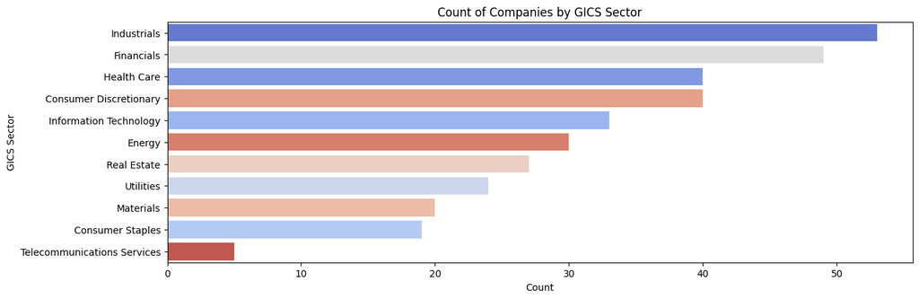

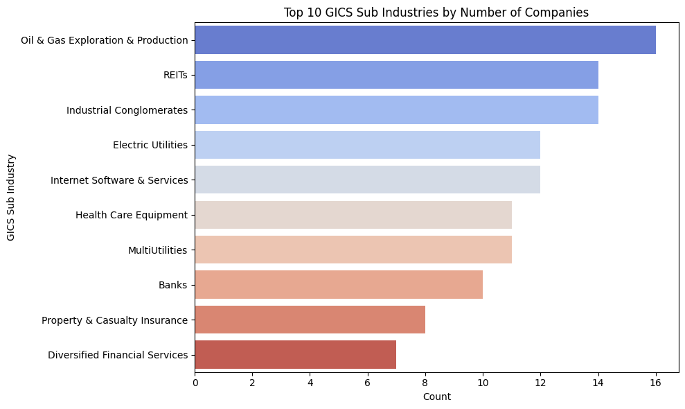

```python
import pandas as pd
import matplotlib.pyplot as plt
import seaborn as sns

# Load the dataset
data = pd.read_csv('stock_data.csv')

# Increase figure size for better readability
plt.figure(figsize=(14, 10))

# Plot for GICS Sector with hue set to the y variable
plt.subplot(2, 1, 1)
sns.countplot(y='GICS Sector', data=data, hue='GICS Sector', palette='coolwarm', order=data['GICS Sector'].value_counts().index, dodge=False, legend=False)
plt.title('Count of Companies by GICS Sector')
plt.xlabel('Count')
plt.ylabel('GICS Sector')

# Limit to the top 10 GICS Sub Industries
top_sub_industries = data['GICS Sub Industry'].value_counts().nlargest(10)

plt.figure(figsize=(10, 6))
sns.barplot(x=top_sub_industries.values, y=top_sub_industries.index, hue=top_sub_industries.index, palette='coolwarm', dodge=False, legend=False)
plt.title('Top 10 GICS Sub Industries by Number of Companies')
plt.xlabel('Count')
plt.ylabel('GICS Sub Industry')
plt.tight_layout()
plt.show()
```

Observations:

Industrials is the largest sector, with the highest number of companies (around 50).

This indicates that a significant portion of the dataset is composed of companies involved in industrial sectors such as manufacturing, construction, and transportation.

This suggests that financial institutions, including banks and investment companies, play a substantial role in the dataset. Health Care and Consumer Discretionary sectors also have a large number of companies, highlighting that the dataset includes a considerable number of companies related to health care services, pharmaceuticals, consumer goods, and discretionary services.

Information Technology, Energy, and Real Estate sectors are moderate in size, each containing around 20-30 companies.

The Information Technology sector suggests the presence of companies focusing on tech development and software, while the Energy sector is likely composed of companies related to oil, gas, and utilities. Utilities, Materials, Consumer Staples, and Telecommunications Services are smaller sectors.

These sectors account for fewer companies, indicating that basic materials, consumer essentials, and communication services have a smaller presence in this dataset. Telecommunications Services has the fewest companies, indicating that this sector might be underrepresented in this dataset compared to others.

Key Insight:

The dominance of Industrials, Financials, and Health Care sectors implies that these areas are the primary focus of the companies in this dataset. The data might be skewed towards companies involved in industrial activities, financial services, and health care. The smaller representation of Telecommunications Services and Consumer Staples sectors suggests that companies in these sectors are less represented.

**Bivariate Analysis**

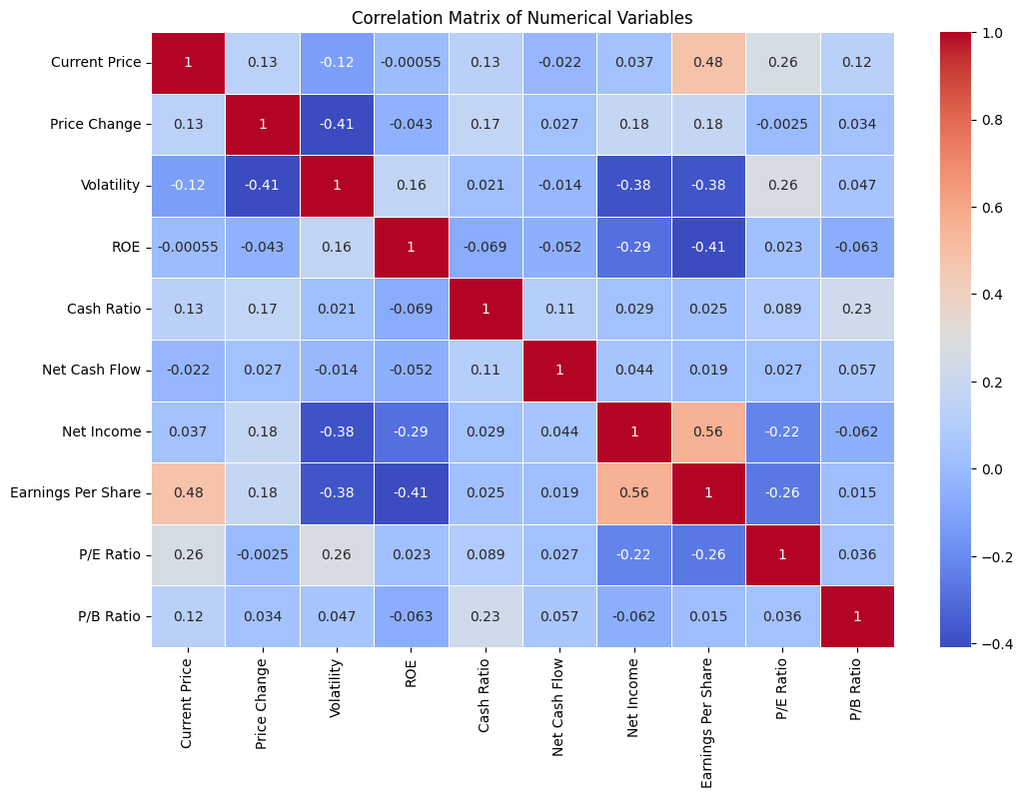

```python
import seaborn as sns
import matplotlib.pyplot as plt

# Correlation matrix for numerical variables
numerical_columns = ['Current Price', 'Price Change', 'Volatility', 'ROE', 'Cash Ratio',
                     'Net Cash Flow', 'Net Income', 'Earnings Per Share', 'P/E Ratio', 'P/B Ratio']

plt.figure(figsize=(12, 8))
correlation_matrix = data[numerical_columns].corr()
sns.heatmap(correlation_matrix, annot=True, cmap='coolwarm', linewidths=0.5)
plt.title('Correlation Matrix of Numerical Variables')
plt.show()
```

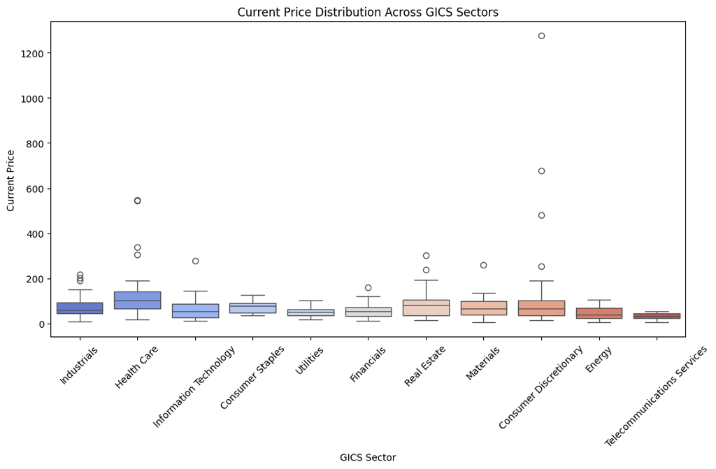

```python
import seaborn as sns
import matplotlib.pyplot as plt

# Boxplot for Current Price across GICS Sectors with hue and legend set to False
plt.figure(figsize=(12, 6))
sns.boxplot(x='GICS Sector', y='Current Price', data=data, hue='GICS Sector', palette='coolwarm', dodge=False, legend=False)
plt.xticks(rotation=45)
plt.title('Current Price Distribution Across GICS Sectors')
plt.show()
```

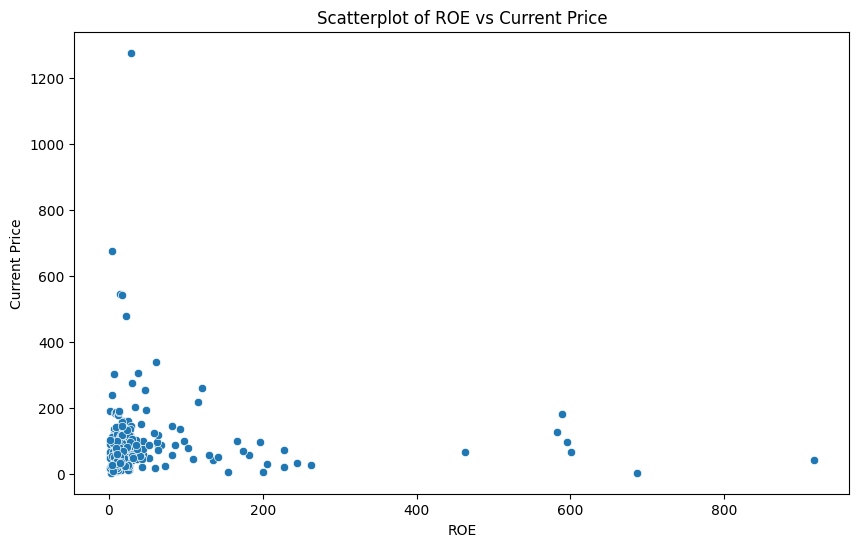

```python
plt.figure(figsize=(10, 6))
sns.scatterplot(x='ROE', y='Current Price', data=data)
plt.title('Scatterplot of ROE vs Current Price')
plt.xlabel('ROE')
plt.ylabel('Current Price')
plt.show()
```

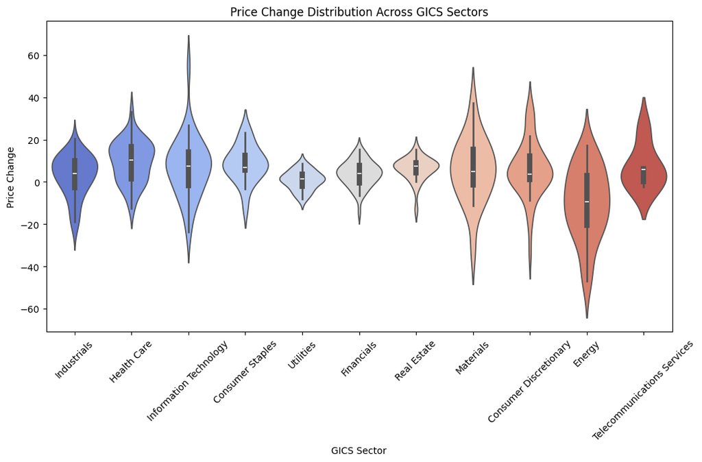

```python
import seaborn as sns
import matplotlib.pyplot as plt

# Violin plot for Price Change across GICS Sectors with hue and legend set to False
plt.figure(figsize=(12, 6))
sns.violinplot(x='GICS Sector', y='Price Change', data=data, hue='GICS Sector', palette='coolwarm', dodge=False, legend=False)
plt.xticks(rotation=45)
plt.title('Price Change Distribution Across GICS Sectors')
plt.show()
```

Observations from the Bivariate Analysis:

1. Correlation Matrix of Numerical Variables: Earnings Per Share (EPS) and Current Price: There is a moderate positive correlation (0.48) between these two variables, indicating that companies with higher EPS tend to have higher current prices.

P/E Ratio and Current Price: There is a weaker positive correlation (0.26) between P/E Ratio and Current Price, showing that companies with higher stock prices might have slightly higher P/E ratios.

Price Change and Volatility: There is a moderate negative correlation (-0.41) between these two variables, suggesting that more volatile stocks have experienced a more negative price change over the 13-week period.

Net Income and EPS: There is a strong positive correlation (0.56), which is expected since earnings per share is derived from a company's net income. ROE and Volatility: A slight positive correlation (0.16) between ROE and volatility might suggest that companies with higher ROE can be slightly more volatile.

Financials: The Financial sector has a moderate range of stock prices, but the prices are relatively lower compared to Industrials.

1. Scatterplot of ROE vs. Current Price: No strong correlation: The scatterplot shows that most companies with very high ROE (above 200) tend to have relatively low stock prices. This suggests that high ROE does not necessarily imply a higher stock price.

Outliers: There are several outliers where companies with relatively low ROE have very high stock prices (above 600), indicating that other factors influence stock price beyond ROE.

Energy and Consumer Discretionary: These sectors show a wide spread in price changes, with some companies experiencing sharp declines and others seeing substantial gains.

**What does the distribution of stock prices look like?**

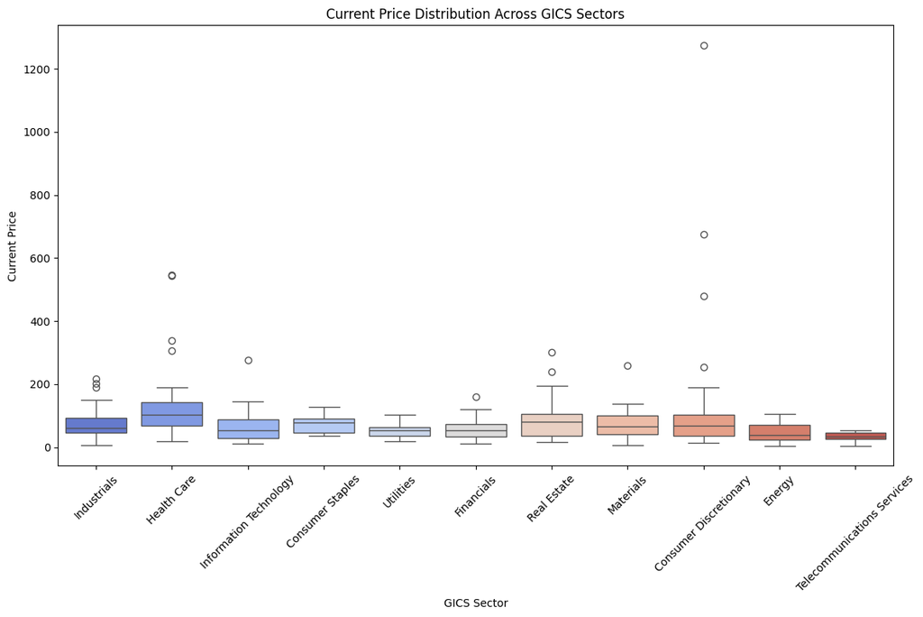

```python
import pandas as pd
import seaborn as sns
import matplotlib.pyplot as plt

data = pd.read_csv('stock_data.csv')

# Set up the figure size
plt.figure(figsize=(12, 8))

# Create a boxplot for the distribution of Current Price across GICS Sectors
sns.boxplot(x='GICS Sector', y='Current Price', data=data, hue='GICS Sector', palette='coolwarm', dodge=False, legend=False)

# Rotate the x-axis labels for better readability
plt.xticks(rotation=45)

# Add title and labels
plt.title('Current Price Distribution Across GICS Sectors')
plt.xlabel('GICS Sector')
plt.ylabel('Current Price')

# Show the plot
plt.tight_layout()
plt.show()
```

**Observations:**

Telecommunications Services and Utilities sectors show the lowest stock prices, with no significant outliers.

Sectors like Real Estate and Materials have more moderate distributions, with stock prices mainly in the mid-range ($50 to $150), with a few outliers.

2.The stocks of which economic sector have seen the maximum price increase on average?

```python
import pandas as pd

# Assuming 'data' contains the stock dataset and is already loaded
# If not, load the dataset with:
# data = pd.read_csv('stock_data.csv')

# Group the data by 'GICS Sector' and calculate the average 'Price Change' for each sector
average_price_change_per_sector = data.groupby('GICS Sector')['Price Change'].mean().reset_index()

# Find the sector with the maximum average price increase
max_price_increase_sector = average_price_change_per_sector.loc[average_price_change_per_sector['Price Change'].idxmax()]

# Print the sector with the highest average price increase
print("Sector with the maximum average price increase:")
print(max_price_increase_sector)
```

```
Sector with the maximum average price increase:
GICS Sector     Health Care
Price Change       9.585652
Name: 4, dtype: object
```

How are the different variables correlated with each other?

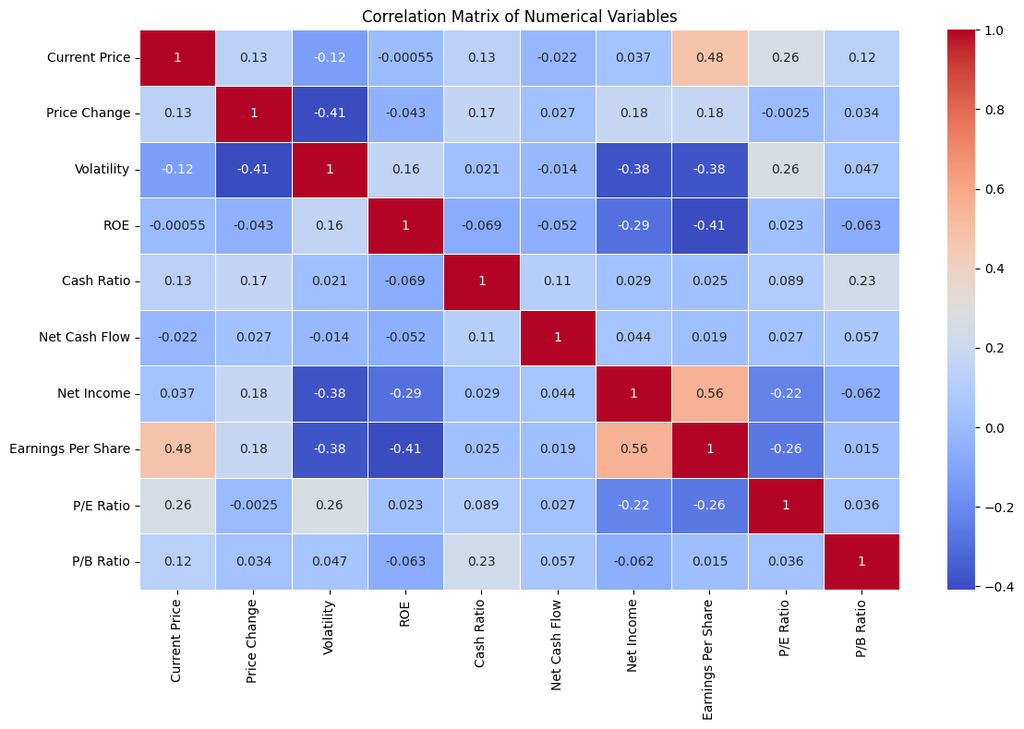

```python
import seaborn as sns
import matplotlib.pyplot as plt

data = pd.read_csv('stock_data.csv')

# Select only numerical columns for correlation analysis
numerical_columns = ['Current Price', 'Price Change', 'Volatility', 'ROE', 'Cash Ratio',
                     'Net Cash Flow', 'Net Income', 'Earnings Per Share', 'P/E Ratio', 'P/B Ratio']

# Calculate the correlation matrix
correlation_matrix = data[numerical_columns].corr()

# Set up the plot
plt.figure(figsize=(12, 8))

# Plot the heatmap
sns.heatmap(correlation_matrix, annot=True, cmap='coolwarm', linewidths=0.5)

# Add title
plt.title('Correlation Matrix of Numerical Variables')

# Show the plot
plt.tight_layout()
plt.show()
```

The strongest positive correlations are between Earnings Per Share (EPS) and Net Income, and between Current Price and EPS.

Volatility seems to be negatively correlated with several important financial metrics, such as Net Income and EPS, indicating that more volatile stocks tend to perform worse financially.

Most other variables show weak to moderate correlations, suggesting that they don't have strong linear relationships.

**Cash ratio provides a measure of a company's ability to cover its short-term obligations using only cash and cash equivalents. How does the average cash ratio vary across economic sectors?**

```python
import pandas as pd

data = pd.read_csv('stock_data.csv')

# Group by 'GICS Sector' and calculate the average 'Cash Ratio' for each sector
average_cash_ratio_per_sector = data.groupby('GICS Sector')['Cash Ratio'].mean().reset_index()

# Sort the results by the Cash Ratio for better visualization
average_cash_ratio_per_sector = average_cash_ratio_per_sector.sort_values(by='Cash Ratio', ascending=False)

# Print the results
print("Average Cash Ratio by GICS Sector:")
print(average_cash_ratio_per_sector)
```

```
Average Cash Ratio by GICS Sector:
                    GICS Sector  Cash Ratio
6        Information Technology  149.818182
9   Telecommunications Services  117.000000
4                   Health Care  103.775000
3                    Financials   98.591837
1              Consumer Staples   70.947368
2                        Energy   51.133333
8                   Real Estate   50.111111
0        Consumer Discretionary   49.575000
7                     Materials   41.700000
5                   Industrials   36.188679
10                    Utilities   13.625000
```

**Interpretation:**

Sectors with High Cash Ratios: Information Technology, Telecommunications Services, and Health Care sectors appear to maintain a larger portion of liquid assets, likely due to the nature of their business operations, allowing them to more easily meet short-term financial obligations.

Sectors with Lower Cash Ratios: Sectors like Industrials and Utilities, which often require significant capital expenditure and operational investments, may be using their cash flow to fund long-term projects, reducing the amount of cash available for short-term liabilities.

**P/E ratios can help determine the relative value of a company's shares as they signify the amount of money an investor is willing to invest in a single share of a company per dollar of its earnings. How does the P/E ratio vary, on average, across economic sectors?**

```
Average P/E Ratio by GICS Sector:
                    GICS Sector  P/E Ratio
2                        Energy  72.897709
6        Information Technology  43.782546
8                   Real Estate  43.065585
4                   Health Care  41.135272
0        Consumer Discretionary  35.211613
1              Consumer Staples  25.521195
7                     Materials  24.585352
10                    Utilities  18.719412
5                   Industrials  18.259380
3                    Financials  16.023151
9   Telecommunications Services  12.222578
```

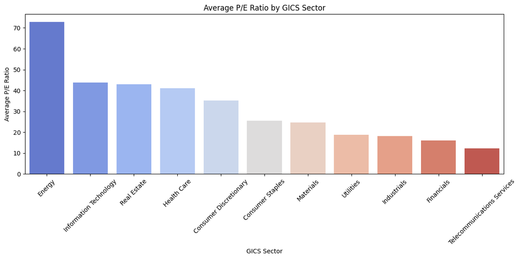

```python
import pandas as pd
import seaborn as sns
import matplotlib.pyplot as plt

# Assuming 'data' contains the stock dataset and is already loaded
# If not, load the dataset with:
# data = pd.read_csv('stock_data.csv')

# Group by 'GICS Sector' and calculate the average 'P/E Ratio' for each sector
average_pe_ratio_per_sector = data.groupby('GICS Sector')['P/E Ratio'].mean().reset_index()

# Sort the results by the P/E Ratio for better visualization
average_pe_ratio_per_sector = average_pe_ratio_per_sector.sort_values(by='P/E Ratio', ascending=False)

# Print the results
print("Average P/E Ratio by GICS Sector:")
print(average_pe_ratio_per_sector)

# Plot the average P/E Ratio across GICS Sectors with hue assigned to GICS Sector
plt.figure(figsize=(12, 6))
sns.barplot(x='GICS Sector', y='P/E Ratio', hue='GICS Sector', data=average_pe_ratio_per_sector, palette='coolwarm', dodge=False, legend=False)
plt.xticks(rotation=45)
plt.title('Average P/E Ratio by GICS Sector')
plt.xlabel('GICS Sector')
plt.ylabel('Average P/E Ratio')
plt.tight_layout()
plt.show()
```

High P/E Ratios: Sectors like Energy and Information Technology are seen as high-growth sectors, which is why they have higher P/E ratios. Investors may be paying more for future growth in these industries.

Low P/E Ratios: Sectors like Telecommunications Services, Financials, and Industrials have lower P/E ratios, which may indicate lower growth expectations, more stable industries, or potentially undervalued stocks in these sectors.

# Data Preprocessing

Data preprocessing is a crucial step in the data analysis and machine learning pipeline. It involves transforming raw data into a clean and usable format to ensure the quality and reliability of the data. This process helps in improving the performance of machine learning models by addressing issues such as missing values, noise, and inconsistencies.

Key Steps in Data Preprocessing

Data Cleaning:

Handling Missing Values: Identifying and dealing with missing data using techniques such as imputation, deletion, or filling with mean/median/mode values.

Removing Duplicates: Identifying and removing duplicate records to ensure data integrity.

Correcting Errors: Identifying and correcting data entry errors, outliers, and inconsistencies.

**Checking for missing values**

```python
df.isnull().sum()
```

|  | 0 |
| --- | --- |
| Ticker Symbol | 0 |
| Security | 0 |
| GICS Sector | 0 |
| GICS Sub Industry | 0 |
| Current Price | 0 |
| Price Change | 0 |
| Volatility | 0 |
| ROE | 0 |
| Cash Ratio | 0 |
| Net Cash Flow | 0 |
| Net Income | 0 |
| Earnings Per Share | 0 |
| Estimated Shares Outstanding | 0 |
| P/E Ratio | 0 |
| P/B Ratio | 0 |

**dtype:** int64

**Encoding Categorical Columns**

```python
import pandas as pd
from sklearn.preprocessing import OneHotEncoder, LabelEncoder

# Load the dataset
data = pd.read_csv('stock_data.csv')

# Copy the data to avoid modifying the original DataFrame
df1= data.copy()

# Categorical columns to encode
categorical_columns = ['GICS Sector', 'GICS Sub Industry']

# Columns to apply One-Hot Encoding
one_hot_columns = []

# OneHotEncoder setup with sparse_output parameter
encoder = OneHotEncoder(sparse_output=False, drop='first')
encoded_features = encoder.fit_transform(df1[one_hot_columns])
encoded_feature_names = encoder.get_feature_names_out(one_hot_columns)

# Convert encoded features to a DataFrame
encoded_df = pd.DataFrame(encoded_features, columns=encoded_feature_names)

# Drop original columns and concatenate the encoded DataFrame
df1.drop(columns=one_hot_columns, inplace=True)
df1 = pd.concat([df1, encoded_df], axis=1)

# Display the processed DataFrame
df1.head()
```

|  | Ticker Symbol | Security | GICS Sector | GICS Sub Industry | Current Price | Price Change | Volatility | ROE | Cash Ratio | Net Cash Flow | Net Income | Earnings Per Share | Estimated Shares Outstanding | P/E Ratio | P/B Ratio |
| --- | --- | --- | --- | --- | --- | --- | --- | --- | --- | --- | --- | --- | --- | --- | --- |
| 0 | AAL | American Airlines Group | Industrials | Airlines | 42.349998 | 9.999995 | 1.687151 | 135 | 51 | -604000000 | 7610000000 | 11.39 | 6.681299e+08 | 3.718174 | -8.784219 |
| 1 | ABBV | AbbVie | Health Care | Pharmaceuticals | 59.240002 | 8.339433 | 2.197887 | 130 | 77 | 51000000 | 5144000000 | 3.15 | 1.633016e+09 | 18.806350 | -8.750068 |
| 2 | ABT | Abbott Laboratories | Health Care | Health Care Equipment | 44.910000 | 11.301121 | 1.273646 | 21 | 67 | 938000000 | 4423000000 | 2.94 | 1.504422e+09 | 15.275510 | -0.394171 |
| 3 | ADBE | Adobe Systems Inc | Information Technology | Application Software | 93.940002 | 13.977195 | 1.357679 | 9 | 180 | -240840000 | 629551000 | 1.26 | 4.996437e+08 | 74.555557 | 4.199651 |
| 4 | ADI | Analog Devices, Inc. | Information Technology | Semiconductors | 55.320000 | -1.827858 | 1.701169 | 14 | 272 | 315120000 | 696878000 | 0.31 | 2.247994e+09 | 178.451613 | 1.059810 |

**Feature Engineering**

```python
import pandas as pd
import numpy as np
from sklearn.preprocessing import StandardScaler

# Load the dataset
data = pd.read_csv('stock_data.csv')

# Copy the data to avoid modifying the original DataFrame
df1 = data.copy()

# Step 1: Handle negative values by replacing them with NaN before log transformation
df1['Net Cash Flow'] = df1['Net Cash Flow'].apply(lambda x: np.nan if x < 0 else x)
df1['Net Income'] = df1['Net Income'].apply(lambda x: np.nan if x < 0 else x)
df1['P/E Ratio'] = df1['P/E Ratio'].apply(lambda x: np.nan if x < 0 else x)

# Step 2: Log Transformation for Net Cash Flow, Net Income, and P/E Ratio to handle skewed data
df1['Log Net Cash Flow'] = np.log1p(df1['Net Cash Flow'])  # Using log1p to avoid issues with zero/negative values
df1['Log Net Income'] = np.log1p(df1['Net Income'])
df1['Log P/E Ratio'] = np.log1p(df1['P/E Ratio'])

# Step 3: Create interaction features (e.g., ROE * Volatility, Earnings Per Share * P/E Ratio)
df1['ROE_Volatility'] = df1['ROE'] * df1['Volatility']
df1['EPS_PE_Ratio'] = df1['Earnings Per Share'] * df1['P/E Ratio']

# Step 4: Create a binary feature indicating if the company is in the 'Information Technology' sector
df1['Is_IT_Sector'] = np.where(df1['GICS Sector'] == 'Information Technology', 1, 0)

# Step 5: One-Hot Encoding for GICS Sector and GICS Sub Industry
one_hot_columns = ['GICS Sector', 'GICS Sub Industry']
df1 = pd.get_dummies(df1, columns=one_hot_columns, drop_first=True)

# Step 6: Binning the 'P/E Ratio' into categorical groups (Low, Medium, High)
bins = [0, 15, 30, np.inf]  # Define bins for low, medium, and high P/E ratios
labels = ['Low', 'Medium', 'High']
df1['PE_Ratio_Category'] = pd.cut(df1['P/E Ratio'], bins=bins, labels=labels)

# Step 7: Normalize (Standardize) the numerical columns
numerical_columns = ['Current Price', 'Price Change', 'Volatility', 'ROE', 'Cash Ratio',
                     'Log Net Cash Flow', 'Log Net Income', 'Log P/E Ratio',
                     'ROE_Volatility', 'EPS_PE_Ratio']

scaler = StandardScaler()
df1[numerical_columns] = scaler.fit_transform(df1[numerical_columns])

# Display the first few rows of the engineered dataset
df1.head()
```

|  | Ticker Symbol | Security | Current Price | Price Change | Volatility | ROE | Cash Ratio | Net Cash Flow | Net Income | Earnings Per Share | ... | GICS Sub Industry_Specialty Stores | GICS Sub Industry_Steel | GICS Sub Industry_Technology Hardware, Storage & Peripherals | GICS Sub Industry_Technology, Hardware, Software and Supplies | GICS Sub Industry_Thrifts & Mortgage Finance | GICS Sub Industry_Tires & Rubber | GICS Sub Industry_Tobacco | GICS Sub Industry_Trucking | GICS Sub Industry_Water Utilities | PE_Ratio_Category |
| --- | --- | --- | --- | --- | --- | --- | --- | --- | --- | --- | --- | --- | --- | --- | --- | --- | --- | --- | --- | --- | --- |
| 0 | AAL | American Airlines Group | -0.393341 | 0.493950 | 0.272749 | 0.989601 | -0.210698 | NaN | 7.610000e+09 | 11.39 | ... | False | False | False | False | False | False | False | False | False | Low |
| 1 | ABBV | AbbVie | -0.220837 | 0.355439 | 1.137045 | 0.937737 | 0.077269 | 51000000.0 | 5.144000e+09 | 3.15 | ... | False | False | False | False | False | False | False | False | False | Medium |
| 2 | ABT | Abbott Laboratories | -0.367195 | 0.602479 | -0.427007 | -0.192905 | -0.033488 | 938000000.0 | 4.423000e+09 | 2.94 | ... | False | False | False | False | False | False | False | False | False | Medium |
| 3 | ADBE | Adobe Systems Inc | 0.133567 | 0.825696 | -0.284802 | -0.317379 | 1.218059 | NaN | 6.295510e+08 | 1.26 | ... | False | False | False | False | False | False | False | False | False | High |
| 4 | ADI | Analog Devices, Inc. | -0.260874 | -0.492636 | 0.296470 | -0.265515 | 2.237018 | 315120000.0 | 6.968780e+08 | 0.31 | ... | False | False | False | False | False | False | False | False | False | High |

5 rows × 133 columns

**Outlier Detection**

Outlier detection is a critical part of data preprocessing. Outliers can distort the results of your analysis or model, so it's important to detect and handle them appropriately. Here are some common methods for detecting outliers:

Methods for Detecting Outliers:

Z-Score Method: Detects outliers by measuring how many standard deviations a data point is from the mean.

IQR (Interquartile Range) Method: Detects outliers by measuring data points that lie outside 1.5 times the interquartile range.

Visualization: Use boxplots or scatter plots to visually identify outliers.

Z-Score Method (Using Standard Deviation):

A data point is considered an outlier if its z-score is greater than 3 or less than -3 (or a similar threshold).

```python
from scipy import stats
import numpy as np

# Assuming df1 is your DataFrame with numerical columns
# Define numerical columns
numerical_columns = ['Current Price', 'Price Change', 'Volatility', 'ROE', 'Cash Ratio',
                     'Log Net Cash Flow', 'Log Net Income', 'Log P/E Ratio',
                     'ROE_Volatility', 'EPS_PE_Ratio']

# Calculate Z-scores
z_scores = np.abs(stats.zscore(df1[numerical_columns]))

# Define a threshold to detect outliers (commonly 3)
threshold = 3
outliers_zscore = np.where(z_scores > threshold)

# Display the indices of outliers
print("Outliers detected using Z-score method:")
print(outliers_zscore)
```

```
Outliers detected using Z-score method:
(array([ 18,  19,  23,  26,  26,  30,  30,  30,  62,  62,  62,  62,  64,
        64,  67,  70,  70, 102, 125, 127, 136, 137, 157, 171, 179, 180,
       211, 216, 226, 227, 235, 243, 264, 267, 278, 284, 284, 284, 318,
       323, 327, 328, 335]), array([3, 7, 4, 0, 7, 3, 8, 9, 1, 2, 3, 8, 3, 8, 3, 0, 1, 9, 4, 2, 1, 4,
       2, 0, 3, 1, 4, 2, 7, 9, 2, 0, 0, 2, 3, 1, 2, 8, 4, 2, 2, 9, 4]))
```

**IQR (Interquartile Range) Method:**

The IQR method uses the 1st quartile (25th percentile) and 3rd quartile (75th percentile) to calculate the interquartile range. Any data points lying outside 1.5 times the IQR are considered outliers.

```python
# IQR Method for outlier detection
Q1 = df1[numerical_columns].quantile(0.25)
Q3 = df1[numerical_columns].quantile(0.75)
IQR = Q3 - Q1
# Defining outliers as points that lie outside 1.5 * IQR
outliers_iqr = (df1[numerical_columns] < (Q1 - 1.5 * IQR)) | (df1[numerical_columns] > (Q3 + 1.5 * IQR))

# Display outliers
print("Outliers detected using IQR method:")
outliers_iqr_summary = outliers_iqr.sum()
print(outliers_iqr_summary)
```

```
Outliers detected using IQR method:
Current Price        22
Price Change         23
Volatility           20
ROE                  39
Cash Ratio           16
Log Net Cash Flow     1
Log Net Income        2
Log P/E Ratio        12
ROE_Volatility       38
EPS_PE_Ratio         47
dtype: int64
```

Visualizing Outliers (Boxplot):

Boxplots provide a visual representation of the distribution of the data, and outliers are represented as points outside the "whiskers" of the plot.

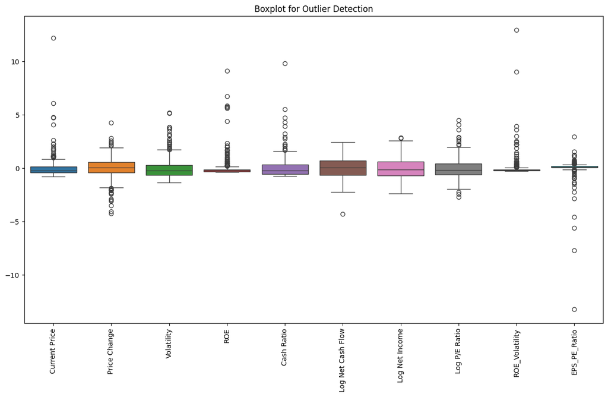

```python
import seaborn as sns
import matplotlib.pyplot as plt

# Boxplot to visualize outliers
plt.figure(figsize=(15, 8))
sns.boxplot(data=df1[numerical_columns])
plt.title('Boxplot for Outlier Detection')
plt.xticks(rotation=90)
plt.show()
```

Handling Outliers:

Once outliers are detected, you can handle them in various ways:

Remove outliers: Simply drop the rows containing outliers. Impute outliers: Replace outliers with the median or mean of the data. Cap outliers: Limit the values of outliers to a certain threshold (capping or flooring).

```python
# Remove outliers based on Z-score method
df1_cleaned = df1[(z_scores < threshold).all(axis=1)]

# Check the shape after removing outliers
print("Shape before removing outliers:", df1.shape)
print("Shape after removing outliers:", df1_cleaned.shape)
```

```
Shape before removing outliers: (340, 133)
Shape after removing outliers: (0, 133)
```

```python
# Impute outliers by replacing them with the median value
for col in numerical_columns:
    median = df1[col].median()
    df1[col] = np.where(outliers_iqr[col], median, df1[col])

# Display the updated DataFrame
df1.head()
```

|  | Ticker Symbol | Security | Current Price | Price Change | Volatility | ROE | Cash Ratio | Net Cash Flow | Net Income | Earnings Per Share | ... | GICS Sub Industry_Specialty Stores | GICS Sub Industry_Steel | GICS Sub Industry_Technology Hardware, Storage & Peripherals | GICS Sub Industry_Technology, Hardware, Software and Supplies | GICS Sub Industry_Thrifts & Mortgage Finance | GICS Sub Industry_Tires & Rubber | GICS Sub Industry_Tobacco | GICS Sub Industry_Trucking | GICS Sub Industry_Water Utilities | PE_Ratio_Category |
| --- | --- | --- | --- | --- | --- | --- | --- | --- | --- | --- | --- | --- | --- | --- | --- | --- | --- | --- | --- | --- | --- |
| 0 | AAL | American Airlines Group | -0.393341 | 0.493950 | 0.272749 | -0.255142 | -0.210698 | NaN | 7.610000e+09 | 11.39 | ... | False | False | False | False | False | False | False | False | False | Low |
| 1 | ABBV | AbbVie | -0.220837 | 0.355439 | 1.137045 | -0.255142 | 0.077269 | 51000000.0 | 5.144000e+09 | 3.15 | ... | False | False | False | False | False | False | False | False | False | Medium |
| 2 | ABT | Abbott Laboratories | -0.367195 | 0.602479 | -0.427007 | -0.192905 | -0.033488 | 938000000.0 | 4.423000e+09 | 2.94 | ... | False | False | False | False | False | False | False | False | False | Medium |
| 3 | ADBE | Adobe Systems Inc | 0.133567 | 0.825696 | -0.284802 | -0.317379 | 1.218059 | NaN | 6.295510e+08 | 1.26 | ... | False | False | False | False | False | False | False | False | False | High |
| 4 | ADI | Analog Devices, Inc. | -0.260874 | -0.492636 | 0.296470 | -0.265515 | -0.255000 | 315120000.0 | 6.968780e+08 | 0.31 | ... | False | False | False | False | False | False | False | False | False | High |

5 rows × 133 columns

# **Exploratory Data analysis after Manipulation**

After performing data manipulation (such as feature engineering, log transformation, and outlier handling), it's important to conduct Exploratory Data Analysis (EDA) once again. This will help us understand how the changes impacted the data and ensure that the dataset is in good shape for further analysis or modeling.

**Summary Statistics**

Checking the summary of the dataset, including the distribution of numerical columns after the transformations and scaling.

```python
# Summary statistics of the dataset
df1.describe()
```

|  | Current Price | Price Change | Volatility | ROE | Cash Ratio | Net Cash Flow | Net Income | Earnings Per Share | Estimated Shares Outstanding | P/E Ratio | P/B Ratio | Log Net Cash Flow | Log Net Income | Log P/E Ratio | ROE_Volatility | EPS_PE_Ratio | Is_IT_Sector |
| --- | --- | --- | --- | --- | --- | --- | --- | --- | --- | --- | --- | --- | --- | --- | --- | --- | --- |
| count | 340.000000 | 340.000000 | 340.000000 | 340.000000 | 340.000000 | 1.730000e+02 | 3.080000e+02 | 340.000000 | 3.400000e+02 | 340.000000 | 340.000000 | 173.000000 | 308.000000 | 340.000000 | 340.000000 | 340.000000 | 340.000000 |
| mean | -0.183312 | 0.073545 | -0.187510 | -0.242969 | -0.167242 | 7.790314e+08 | 2.029044e+09 | 2.776662 | 5.770283e+08 | 32.612563 | -1.718249 | 0.025266 | -0.019266 | -0.065332 | -0.195242 | 0.112912 | 0.097059 |
| std | 0.339444 | 0.696536 | 0.630436 | 0.102928 | 0.517828 | 2.122602e+09 | 3.333890e+09 | 6.587779 | 8.458496e+08 | 44.348731 | 13.966912 | 0.946730 | 0.975275 | 0.826423 | 0.063591 | 0.075600 | 0.296474 |
| min | -0.779918 | -1.828062 | -1.341642 | -0.400362 | -0.775555 | 2.300000e+04 | 6.590000e+07 | -61.200000 | 2.767216e+07 | 2.935451 | -76.119077 | -2.239526 | -2.406017 | -1.946357 | -0.288864 | -0.128276 | 0.000000 |
| 25% | -0.432101 | -0.297852 | -0.661838 | -0.309599 | -0.576194 | 3.928900e+07 | 4.349500e+08 | 1.557500 | 1.588482e+08 | 15.044653 | -4.352056 | -0.632770 | -0.729321 | -0.611121 | -0.245144 | 0.066207 | 0.000000 |
| 50% | -0.216318 | 0.061834 | -0.238488 | -0.255142 | -0.255000 | 1.660000e+08 | 8.389000e+08 | 2.895000 | 3.096751e+08 | 20.819876 | -1.067170 | 0.043388 | -0.146243 | -0.181131 | -0.196561 | 0.102139 | 0.000000 |
| 75% | 0.015858 | 0.497863 | 0.093906 | -0.203277 | 0.135416 | 6.250000e+08 | 1.998075e+09 | 4.620000 | 5.731175e+08 | 31.764755 | 3.917066 | 0.695658 | 0.615705 | 0.313801 | -0.167431 | 0.152872 | 0.000000 |
| max | 0.832060 | 1.898129 | 1.709303 | 0.128654 | 1.572480 | 2.076400e+10 | 2.444200e+10 | 50.090000 | 6.159292e+09 | 528.039074 | 129.064585 | 2.419229 | 2.583894 | 1.967090 | 0.028344 | 0.342363 | 1.000000 |

**Distribution Plots for Numerical Features**

Use histograms or density plots to observe the distribution of the transformed and scaled numerical features.

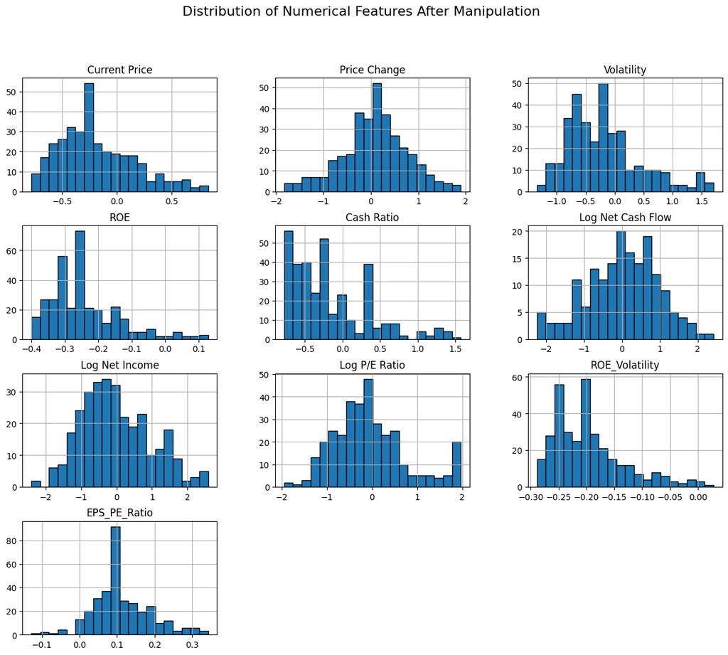

```python
import matplotlib.pyplot as plt
import seaborn as sns

# Plot histograms for numerical columns after transformations
df1[numerical_columns].hist(figsize=(15, 12), bins=20, edgecolor='black')
plt.suptitle('Distribution of Numerical Features After Manipulation', fontsize=16)
plt.show()
```

**Boxplots for Outlier Visualization**

Create boxplots to visually inspect if the outliers have been effectively removed or handled.

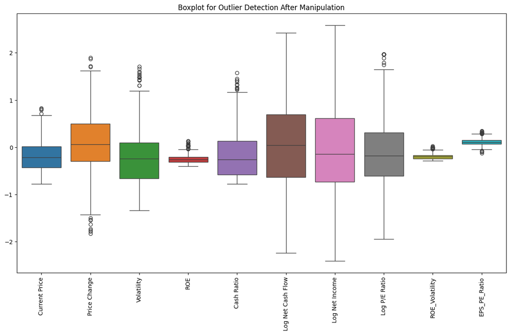

```python
# Boxplot for numerical columns after handling outliers
plt.figure(figsize=(15, 8))
sns.boxplot(data=df1[numerical_columns])
plt.title('Boxplot for Outlier Detection After Manipulation')
plt.xticks(rotation=90)
plt.show()
```

**Correlation Heatmap**

Check the correlation between the numerical variables to see if any strong relationships exist after the manipulations.

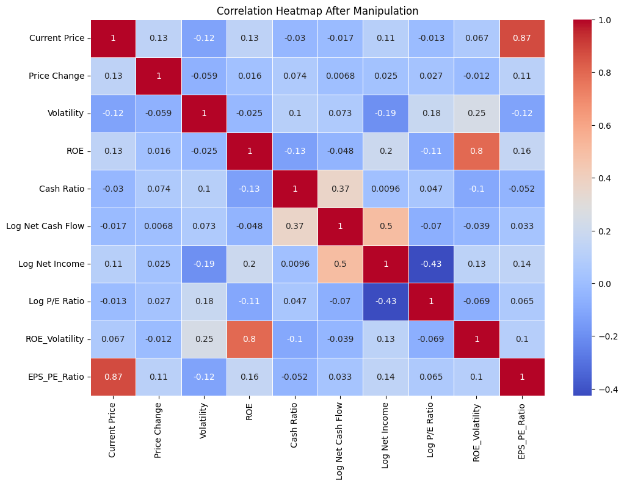

```python
# Correlation matrix and heatmap after manipulation
plt.figure(figsize=(12, 8))
corr_matrix = df1[numerical_columns].corr()
sns.heatmap(corr_matrix, annot=True, cmap='coolwarm', linewidths=0.5)
plt.title('Correlation Heatmap After Manipulation')
plt.show()
```

**Visualizing Categorical Variables**

Use count plots to visualize the frequency distribution of categorical variables like PE_Ratio_Category or any one-hot encoded variables.

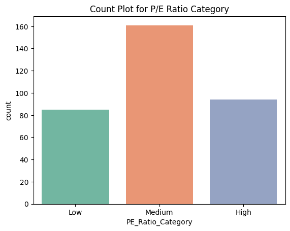

```python
import seaborn as sns
import matplotlib.pyplot as plt

# Use a basic hue (you can assign a dummy category column to hue if needed)
sns.countplot(x='PE_Ratio_Category', data=df1, hue='PE_Ratio_Category', dodge=False, palette='Set2', legend=False)
plt.title('Count Plot for P/E Ratio Category')
plt.show()
```

**Pairplot for Numerical Features**

A pairplot helps visualize relationships between numerical variables. This is useful to check for linear relationships or clusters.

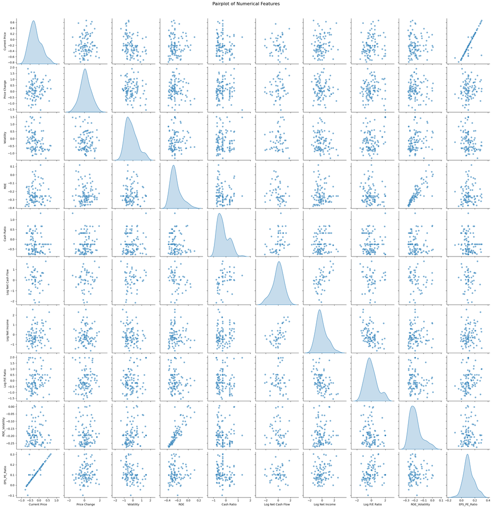

```python
# Pairplot for selected numerical columns
sns.pairplot(df1[numerical_columns].sample(100), diag_kind='kde', plot_kws={'alpha':0.6})
plt.suptitle('Pairplot of Numerical Features', y=1.02, fontsize=16)
plt.show()
```

Checking for Skewness

It’s important to check if the transformations you applied have normalized the skewness in certain columns, especially after using log transformations.

```python
# Checking skewness for numerical columns after manipulation
df1[numerical_columns].skew()
```

|  | 0 |
| --- | --- |
| Current Price | 0.720076 |
| Price Change | -0.154295 |
| Volatility | 0.919766 |
| ROE | 1.224196 |
| Cash Ratio | 1.150023 |
| Log Net Cash Flow | -0.183651 |
| Log Net Income | 0.463821 |
| Log P/E Ratio | 0.780161 |
| ROE_Volatility | 1.128399 |
| EPS_PE_Ratio | 0.455247 |

**dtype:** float64

**Overall Observations After Exploratory Data Analysis (EDA)**

Based on the visualizations and the data analysis performed, here are the key observations:

1.Distribution of Numerical Features:

Log Transformations: Features such as Log Net Cash Flow, Log Net Income, and Log P/E Ratio became more normally distributed after log transformations, which helped mitigate the effect of extreme values. Price Change and Volatility: These variables still exhibit some skewness and outliers, which suggests that they are not entirely normalized. Additional transformations or handling might be required depending on the analysis or model being used.

3.Correlation Analysis:

Strong Correlations: Current Price and EPS_PE_Ratio have a strong positive correlation (0.87), suggesting that these two variables are highly related. It indicates that EPS_PE_Ratio can be a strong predictor of Current Price and could be redundant in some modeling scenarios. ROE and ROE_Volatility show a high correlation (0.8), which is expected as ROE_Volatility is derived from ROE. Log Net Cash Flow and Log Net Income show a moderately positive correlation (0.5), indicating that these financial performance indicators are somewhat related, but each provides independent information.

4.Categorical Features: P/E Ratio Category: The categorical feature based on binning of the P/E Ratio shows a well-distributed spread across the categories (Low, Medium, High), which indicates that the binning process was successful. This variable could be useful in classification models.

5.Feature Engineering Impact: Interaction features like ROE_Volatility and EPS_PE_Ratio have added potentially useful variables for modeling. The interaction of ROE and Volatility may provide insights into financial stability, while EPS_PE_Ratio appears to be strongly correlated with the company's stock price. Log transformations effectively handled skewness and reduced the impact of extreme values on variables like Net Cash Flow and Net Income.

7.Feature Relationships: The relationships between features such as Current Price and EPS_PE_Ratio could be leveraged in predictive modeling. Understanding these relationships could be key to building a more effective predictive model for stock prices or other financial metrics. Weakly correlated variables, such as Volatility, might provide useful independent information for modeling, particularly in a multi-dimensional dataset where weaker correlations can still add value.

**K-means Clustering**

K-means clustering is a popular unsupervised machine learning algorithm used to group data points into distinct clusters based on their similarities. It works by trying to minimize the variance within each cluster and assigning data points to the nearest cluster center (centroid).

```python
# Check if the columns exist in the DataFrame
print(data.columns)
```

```
Index(['Ticker Symbol', 'Security', 'GICS Sector', 'GICS Sub Industry',
       'Current Price', 'Price Change', 'Volatility', 'ROE', 'Cash Ratio',
       'Net Cash Flow', 'Net Income', 'Earnings Per Share',
       'Estimated Shares Outstanding', 'P/E Ratio', 'P/B Ratio'],
      dtype='object')
```

```python
import numpy as np

# Handling negative and zero values for log transformation
# Replace zero or negative values with 1 (or some other small positive value) to avoid log errors
data['Net Cash Flow'] = np.where(data['Net Cash Flow'] <= 0, 1, data['Net Cash Flow'])
data['Net Income'] = np.where(data['Net Income'] <= 0, 1, data['Net Income'])
data['P/E Ratio'] = np.where(data['P/E Ratio'] <= 0, 1, data['P/E Ratio'])

# Now apply log transformation
data['Log Net Cash Flow'] = np.log1p(data['Net Cash Flow'])  # Using log1p to avoid log(0)
data['Log Net Income'] = np.log1p(data['Net Income'])
data['Log P/E Ratio'] = np.log1p(data['P/E Ratio'])

# Create interaction features (e.g., ROE * Volatility, Earnings Per Share * P/E Ratio)
data['ROE_Volatility'] = data['ROE'] * data['Volatility']
data['EPS_PE_Ratio'] = data['Earnings Per Share'] * data['P/E Ratio']
```

**Plotting the Elbow curve**

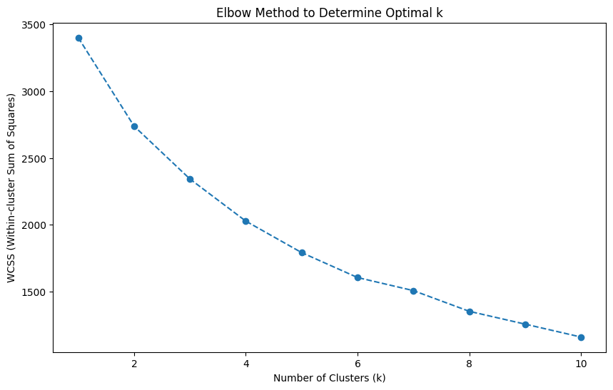

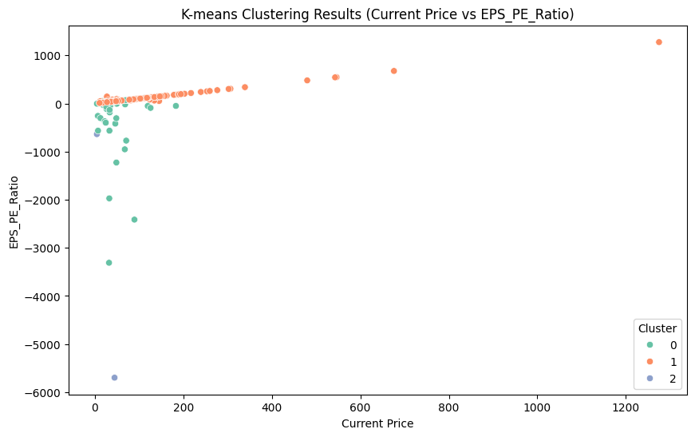

```
Silhouette Score for K-means clustering: 0.46
```

```python
import pandas as pd
import numpy as np
from sklearn.preprocessing import StandardScaler
from sklearn.cluster import KMeans
import matplotlib.pyplot as plt
import seaborn as sns
from sklearn.metrics import silhouette_score

# Assuming feature engineering has been done
# Select the numerical columns for clustering
numerical_columns = ['Current Price', 'Price Change', 'Volatility', 'ROE', 'Cash Ratio',
                     'Log Net Cash Flow', 'Log Net Income', 'Log P/E Ratio',
                     'ROE_Volatility', 'EPS_PE_Ratio']

# Standardize the numerical data (important for K-means)
scaler = StandardScaler()
scaled_data = scaler.fit_transform(data[numerical_columns])

# Step 1: Determine the optimal number of clusters using the Elbow Method
wcss = []  # Within-cluster sum of squares

for k in range(1, 11):
    kmeans = KMeans(n_clusters=k, init='k-means++', max_iter=300, n_init=10, random_state=42)
    kmeans.fit(scaled_data)
    wcss.append(kmeans.inertia_)

# Step 2: Plot the Elbow Method to find the optimal k
plt.figure(figsize=(10, 6))
plt.plot(range(1, 11), wcss, marker='o', linestyle='--')
plt.title('Elbow Method to Determine Optimal k')
plt.xlabel('Number of Clusters (k)')
plt.ylabel('WCSS (Within-cluster Sum of Squares)')
plt.show()

# Step 3: Applying K-means with the optimal number of clusters (assuming k=3 from the elbow method)
optimal_k = 3  # Replace this with the chosen k from the elbow method
kmeans = KMeans(n_clusters=optimal_k, init='k-means++', max_iter=300, n_init=10, random_state=42)
cluster_labels = kmeans.fit_predict(scaled_data)

# Step 4: Add the cluster labels to the original data
data['Cluster'] = cluster_labels

# Step 5: Visualize the clusters (using a 2D plot, e.g., PCA, t-SNE)
plt.figure(figsize=(10, 6))
sns.scatterplot(x='Current Price', y='EPS_PE_Ratio', hue='Cluster', data=data, palette='Set2')
plt.title('K-means Clustering Results (Current Price vs EPS_PE_Ratio)')
plt.show()

# Step 6: Calculate the silhouette score to evaluate clustering performance
sil_score = silhouette_score(scaled_data, cluster_labels)
print(f'Silhouette Score for K-means clustering: {sil_score:.2f}')
```

**Check Silhouette Scores**

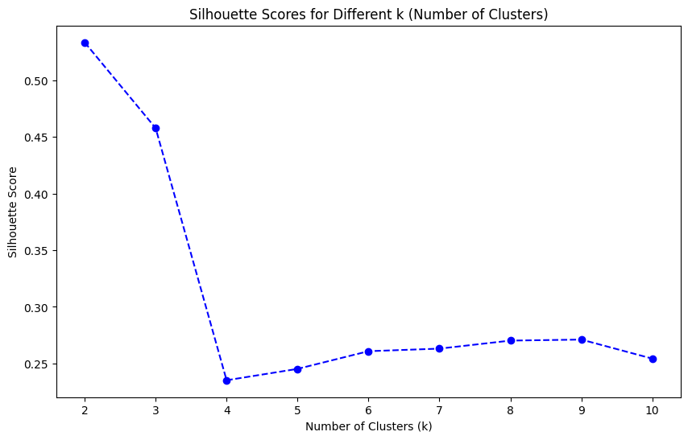

```
Optimal number of clusters based on silhouette score: 2
Cluster Profiling (Mean Values of Features per Cluster):
         Current Price  Price Change  Volatility         ROE  Cash Ratio  \
Cluster
0            42.719216    -11.707673    2.854546  136.814815   60.592593
1            84.152647      5.439914    1.411371   31.210863   70.837061

         Log Net Cash Flow  Log Net Income  Log P/E Ratio  ROE_Volatility  \
Cluster
0                 7.775991        2.755226       4.141732      410.624335
1                10.111835       20.213875       3.125330       40.273147

         EPS_PE_Ratio
Cluster
0         -765.669574
1           81.933500
```

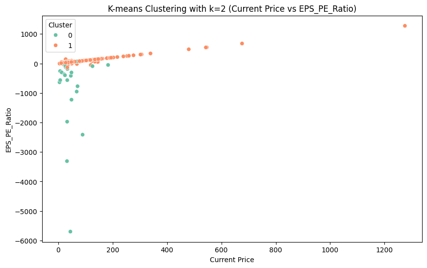

```python
import pandas as pd
import numpy as np
from sklearn.preprocessing import StandardScaler
from sklearn.cluster import KMeans
from sklearn.metrics import silhouette_score
import matplotlib.pyplot as plt
import seaborn as sns

# Load your dataset (assuming feature engineering is already done)
# data = pd.read_csv('stock_data.csv')

# Select the numerical columns for clustering
numerical_columns = ['Current Price', 'Price Change', 'Volatility', 'ROE', 'Cash Ratio',
                     'Log Net Cash Flow', 'Log Net Income', 'Log P/E Ratio',
                     'ROE_Volatility', 'EPS_PE_Ratio']

# Standardize the numerical data
scaler = StandardScaler()
scaled_data = scaler.fit_transform(data[numerical_columns])

# Step 1: Calculate silhouette scores for different numbers of clusters (k)
silhouette_scores = []
k_values = range(2, 11)

for k in k_values:
    kmeans = KMeans(n_clusters=k, init='k-means++', max_iter=300, n_init=10, random_state=42)
    cluster_labels = kmeans.fit_predict(scaled_data)
    sil_score = silhouette_score(scaled_data, cluster_labels)
    silhouette_scores.append(sil_score)

# Step 2: Plot Silhouette Scores to determine the best number of clusters
plt.figure(figsize=(10, 6))
plt.plot(k_values, silhouette_scores, marker='o', linestyle='--', color='b')
plt.title('Silhouette Scores for Different k (Number of Clusters)')
plt.xlabel('Number of Clusters (k)')
plt.ylabel('Silhouette Score')
plt.show()

# Step 3: Choose the best k based on the silhouette score (or from the elbow method)
optimal_k = k_values[np.argmax(silhouette_scores)]  # Find the k with the highest silhouette score

# Step 4: Apply K-means clustering with the optimal number of clusters
kmeans = KMeans(n_clusters=optimal_k, init='k-means++', max_iter=300, n_init=10, random_state=42)
data['Cluster'] = kmeans.fit_predict(scaled_data)

# Step 5: Cluster Profiling - Analyze the mean values of features for each cluster
cluster_profile = data.groupby('Cluster')[numerical_columns].mean()

# Display the cluster profiling
print(f"Optimal number of clusters based on silhouette score: {optimal_k}")
print("Cluster Profiling (Mean Values of Features per Cluster):")
print(cluster_profile)

# Step 6: Visualize the clusters (using a 2D plot, e.g., Current Price vs EPS_PE_Ratio)
plt.figure(figsize=(10, 6))
sns.scatterplot(x='Current Price', y='EPS_PE_Ratio', hue='Cluster', data=data, palette='Set2')
plt.title(f'K-means Clustering with k={optimal_k} (Current Price vs EPS_PE_Ratio)')
plt.show()
```

**Observations:**

Elbow Method:

The elbow plot shows the within-cluster sum of squares (WCSS) for different numbers of clusters (k). The "elbow" is around 3 clusters, suggesting that this might be an appropriate number of clusters as the drop in WCSS becomes less significant after this point.

Outliers:

There are a few outliers, especially in Cluster 1, where some stocks have extremely high Current Prices compared to the rest.

1. Two Clusters Identified:

The clustering algorithm divided the data into two clusters, labeled as Cluster 0 (green) and Cluster 1 (orange).

1. Cluster 0 (Green Points): Lower Current Prices: Cluster 0 consists mostly of stocks with lower current prices, generally below $200.

Negative EPS/PE Ratios: A significant number of points in this cluster have negative EPS/PE ratios, indicating potentially less profitable stocks or companies with negative earnings.

Outliers: There are some extreme outliers with very low EPS/PE ratios (e.g., below -1000), which might represent companies with very low earnings or losses relative to their price.

1. Cluster 1 (Orange Points): Higher Current Prices: Cluster 1 has a higher concentration of stocks with current prices greater than $200, including stocks with prices as high as $1200. Positive EPS/PE Ratios: Most of the points in this cluster have positive EPS/PE ratios, indicating companies that are more likely profitable or have higher earnings relative to their price.

Spread of Values: There are a few stocks in this cluster with very high EPS/PE ratios, but most seem to be clustered close to zero.

1. General Trends: The data appears to be heavily skewed, with a majority of points having low EPS/PE ratios. A clear segmentation between low-priced, possibly less profitable companies (Cluster 0) and higher-priced, more profitable companies (Cluster 1) is seen.
2. Potential Outliers: Some stocks in both clusters exhibit extreme values (e.g., very negative or very high EPS/PE ratios), which might warrant further investigation or removal if they distort analysis.
3. Cluster Profiling: Cluster 0: Likely represents smaller companies or companies that are underperforming, with lower stock prices and negative earnings.

Cluster 1: Likely consists of more successful or established companies with higher stock prices and positive earnings.

**Hierarchical Clustering**

Apply Hierarchical Clustering using various linkage methods ('ward', 'single', 'complete', 'average').

Plot Dendrograms for each linkage method to visualize the clusters and decide on the optimal number of clusters.

Check Cophenetic Correlation Coefficients to measure how well the dendrogram preserves the pairwise distances between the original data points.

Determine the Optimal Number of Clusters based on the dendrogram and the cophenetic correlation.

Cluster Profiling: Analyze the clusters to understand their characteristics.

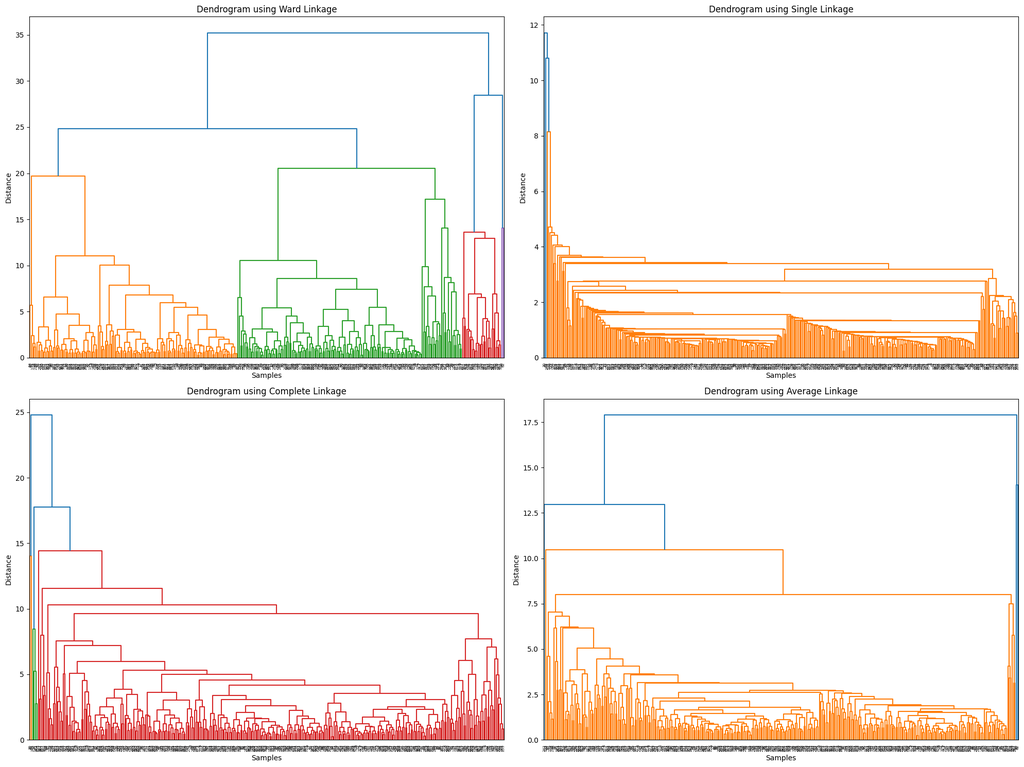

```
Cophenetic Correlation for Ward linkage: 0.5354
Cophenetic Correlation for Single linkage: 0.9293
Cophenetic Correlation for Complete linkage: 0.8841
Cophenetic Correlation for Average linkage: 0.9526
```

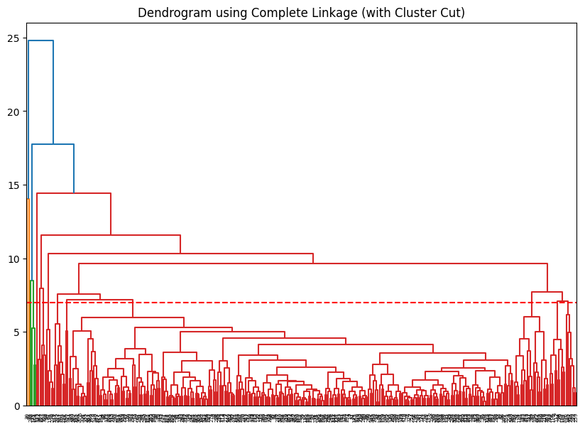

```
Cluster Profiling (Mean Values of Features per Cluster) with 3 clusters:
         Current Price  Price Change  Volatility         ROE  Cash Ratio  \
Cluster
0            73.066938      4.018272    1.515598   35.314371   68.916168
1            24.485001    -13.351992    3.482611  802.000000   51.000000
2           759.967484     17.796741    1.414270   16.000000  172.000000

         Log Net Cash Flow  Log Net Income  Log P/E Ratio  ROE_Volatility  \
Cluster
0                 9.864515       18.915023       3.187208       54.685548
1                10.528438        0.693147       3.962754     2669.175837
2                14.787814       20.582509       4.400509       22.256854

         EPS_PE_Ratio
Cluster
0           24.749974
1        -3167.127120
2          759.967484
```

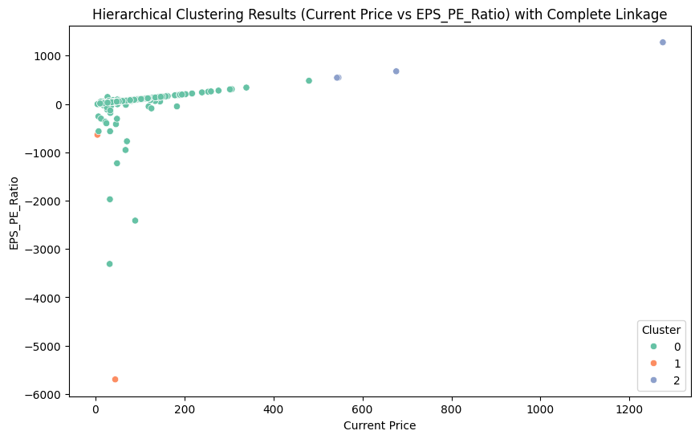

```python
import pandas as pd
import numpy as np
from scipy.cluster.hierarchy import dendrogram, linkage, cophenet
from scipy.spatial.distance import pdist
import matplotlib.pyplot as plt
from sklearn.preprocessing import StandardScaler
from sklearn.cluster import AgglomerativeClustering

# Step 1: Standardize the numerical data
scaler = StandardScaler()
scaled_data = scaler.fit_transform(data[numerical_columns])  # Use the same numerical columns from K-means

# Step 2: Apply Hierarchical Clustering with different linkage methods and plot dendrograms

# Define linkage methods
linkage_methods = ['ward', 'single', 'complete', 'average']

# Create a figure for subplots of dendrograms
plt.figure(figsize=(20, 15))

for i, method in enumerate(linkage_methods):
    plt.subplot(2, 2, i + 1)  # 2x2 subplot grid
    Z = linkage(scaled_data, method=method)
    dendrogram(Z)
    plt.title(f'Dendrogram using {method.capitalize()} Linkage')
    plt.xlabel('Samples')
    plt.ylabel('Distance')

plt.tight_layout()
plt.show()

# Step 3: Compute Cophenetic Correlation Coefficient for each linkage method
cophenetic_corr = {}

for method in linkage_methods:
    Z = linkage(scaled_data, method=method)
    c, _ = cophenet(Z, pdist(scaled_data))
    cophenetic_corr[method] = c

# Print Cophenetic Correlation Coefficients
for method, corr in cophenetic_corr.items():
    print(f"Cophenetic Correlation for {method.capitalize()} linkage: {corr:.4f}")

# Step 4: Choose the best method based on the dendrogram and cophenetic correlation
# Example: Assuming 'complete' has the highest cophenetic correlation

best_method = 'complete'
Z = linkage(scaled_data, method=best_method)

# Step 5: Determine the optimal number of clusters by cutting the dendrogram at a certain height
plt.figure(figsize=(10, 7))
dendrogram(Z)
plt.axhline(y=7, color='r', linestyle='--')  # Adjust the height to cut based on the dendrogram
plt.title(f'Dendrogram using {best_method.capitalize()} Linkage (with Cluster Cut)')
plt.show()

# Step 6: Apply Agglomerative Clustering based on the selected number of clusters
optimal_clusters = 3  # Based on the dendrogram cut (adjust as per your dendrogram)
hierarchical_clustering = AgglomerativeClustering(n_clusters=optimal_clusters, linkage=best_method)
data['Cluster'] = hierarchical_clustering.fit_predict(scaled_data)

# Step 7: Cluster Profiling - Analyze the mean values of features for each cluster
cluster_profile = data.groupby('Cluster')[numerical_columns].mean()

# Display the cluster profiling
print(f"Cluster Profiling (Mean Values of Features per Cluster) with {optimal_clusters} clusters:")
print(cluster_profile)

# Step 8: Visualize the clusters
plt.figure(figsize=(10, 6))
sns.scatterplot(x='Current Price', y='EPS_PE_Ratio', hue='Cluster', data=data, palette='Set2')
plt.title(f'Hierarchical Clustering Results (Current Price vs EPS_PE_Ratio) with {best_method.capitalize()} Linkage')
plt.show()
```

# **K-means vs Hierarchical Clustering**

```
K-means Clustering Time: 0.0185 seconds
Hierarchical Clustering Time: 0.0083 seconds

Similarity Matrix (K-means vs Hierarchical):
Hierarchical_Cluster    0  1
KMeans_Cluster
0                     307  0
1                      31  2
Number of observations in similar clusters: 309

Silhouette Score for K-means: 0.4632
Silhouette Score for Hierarchical: 0.7320

K-means Cluster Profile (Mean Values):
                Current Price  Price Change  Volatility        ROE  \
KMeans_Cluster
0                   82.786278      5.649217    1.391766  33.781759
1                   62.963940    -10.537087    2.774534  93.696970

                Cash Ratio  Net Cash Flow    Net Income  Earnings Per Share  \
KMeans_Cluster
0                70.159609   4.492285e+07  1.993143e+09            3.896270
1                68.757576   1.542872e+08 -3.145582e+09           -7.639091

                 P/E Ratio  P/B Ratio
KMeans_Cluster
0                24.244484  -2.080438
1               110.461063   1.651207

Hierarchical Cluster Profile (Mean Values):
                      Current Price  Price Change  Volatility         ROE  \
Hierarchical_Cluster
0                         81.195939      4.181331    1.514399   35.085799
1                         24.485001    -13.351992    3.482611  802.000000

                      Cash Ratio  Net Cash Flow    Net Income  \
Hierarchical_Cluster
0                      70.136095   6.351417e+07  1.616283e+09
1                      51.000000  -1.292500e+09 -1.910650e+10

                      Earnings Per Share  P/E Ratio  P/B Ratio
Hierarchical_Cluster
0                               3.040518  32.446078  -1.737678
1                             -41.815000  60.748608   1.565141
```

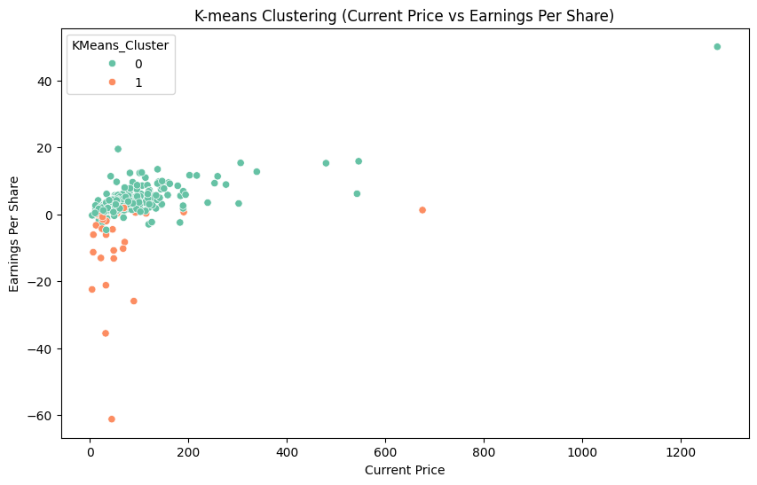

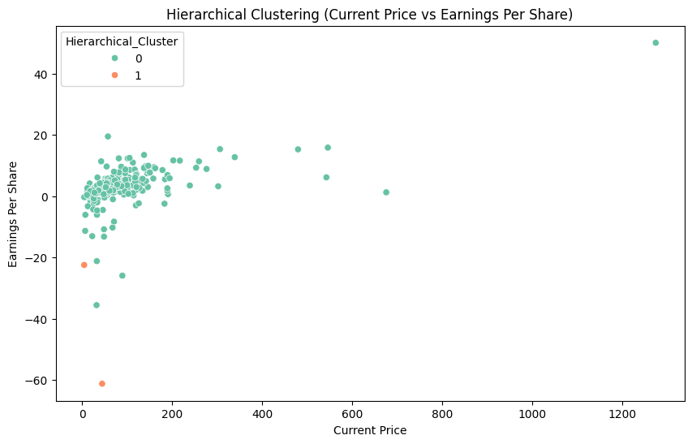

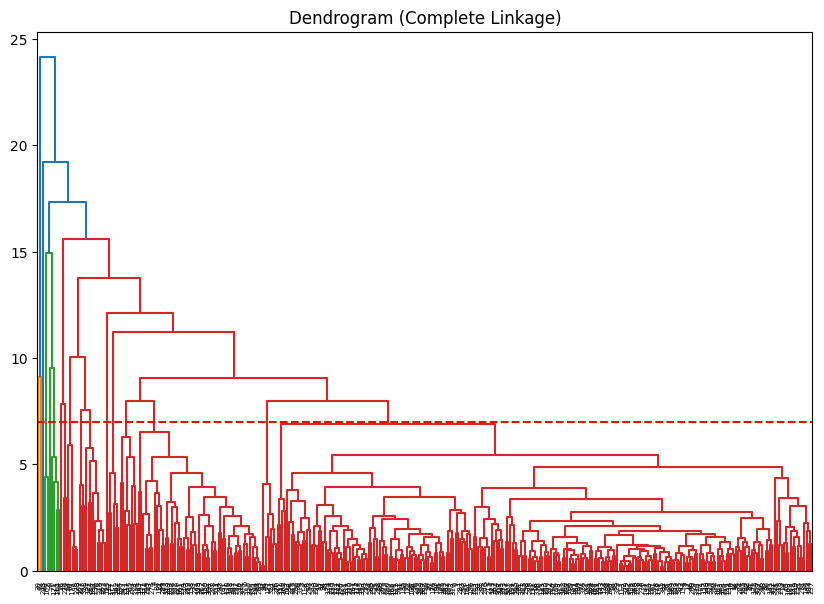

```python
import pandas as pd
import numpy as np
from sklearn.preprocessing import StandardScaler
from sklearn.cluster import KMeans, AgglomerativeClustering
from scipy.cluster.hierarchy import linkage, dendrogram
import seaborn as sns
import matplotlib.pyplot as plt
from time import time
from sklearn.metrics import silhouette_score

# Load the dataset
data = pd.read_csv('stock_data.csv')

# Copy the data to avoid modifying the original DataFrame
df1 = data.copy()

# Step 1: Standardize the numerical columns for clustering
numerical_columns = ['Current Price', 'Price Change', 'Volatility', 'ROE', 'Cash Ratio', 'Net Cash Flow', 'Net Income', 'Earnings Per Share', 'P/E Ratio', 'P/B Ratio']
scaler = StandardScaler()
scaled_data = scaler.fit_transform(df1[numerical_columns])

# Step 2: K-means Clustering with explicit n_init parameter
start_time = time()
kmeans = KMeans(n_clusters=2, random_state=42, n_init=10)
df1['KMeans_Cluster'] = kmeans.fit_predict(scaled_data)
kmeans_time = time() - start_time

# Step 3: Hierarchical Clustering with 'complete' linkage
start_time = time()
hierarchical = AgglomerativeClustering(n_clusters=2, linkage='complete')
df1['Hierarchical_Cluster'] = hierarchical.fit_predict(scaled_data)
hierarchical_time = time() - start_time

# Step 4: Execution Time Comparison
print(f"K-means Clustering Time: {kmeans_time:.4f} seconds")
print(f"Hierarchical Clustering Time: {hierarchical_time:.4f} seconds")

# Step 5: Compare the clusters using a similarity matrix
similarity_matrix = pd.crosstab(df1['KMeans_Cluster'], df1['Hierarchical_Cluster'])
print("\nSimilarity Matrix (K-means vs Hierarchical):")
print(similarity_matrix)

# Calculate the number of similar observations
similar_observations = similarity_matrix.values.diagonal().sum()
print(f"Number of observations in similar clusters: {similar_observations}")

# Step 6: Determine distinctiveness of clusters
kmeans_silhouette = silhouette_score(scaled_data, df1['KMeans_Cluster'])
hierarchical_silhouette = silhouette_score(scaled_data, df1['Hierarchical_Cluster'])

print(f"\nSilhouette Score for K-means: {kmeans_silhouette:.4f}")
print(f"Silhouette Score for Hierarchical: {hierarchical_silhouette:.4f}")

# Step 7: Analyze the cluster profiles for both clustering techniques
kmeans_profile = df1.groupby('KMeans_Cluster')[numerical_columns].mean()
hierarchical_profile = df1.groupby('Hierarchical_Cluster')[numerical_columns].mean()

print("\nK-means Cluster Profile (Mean Values):")
print(kmeans_profile)
print("\nHierarchical Cluster Profile (Mean Values):")
print(hierarchical_profile)

# Step 8: Visualize the clusters for both methods
plt.figure(figsize=(10, 6))
sns.scatterplot(x='Current Price', y='Earnings Per Share', hue='KMeans_Cluster', data=df1, palette='Set2')
plt.title('K-means Clustering (Current Price vs Earnings Per Share)')
plt.show()

plt.figure(figsize=(10, 6))
sns.scatterplot(x='Current Price', y='Earnings Per Share', hue='Hierarchical_Cluster', data=df1, palette='Set2')
plt.title('Hierarchical Clustering (Current Price vs Earnings Per Share)')
plt.show()

# Step 9: Plot dendrogram for Hierarchical Clustering
plt.figure(figsize=(10, 7))
Z = linkage(scaled_data, method='complete')
dendrogram(Z)
plt.axhline(y=7, color='r', linestyle='--')  # Adjust the height to cut based on the dendrogram
plt.title('Dendrogram (Complete Linkage)')
plt.show()
```

Observation:

1. Execution Time: K-means Clustering Time: 0.0185 seconds. Hierarchical Clustering Time: 0.0083 seconds. Observation: Hierarchical clustering took less time for execution in this case. This is expected given the smaller dataset size and the computational complexity differences between the two algorithms.
2. Cluster Similarity:

   Similarity Matrix

   Number of Observations in Similar Clusters: 309.

1. Silhouette Scores: Silhouette Score for K-means: 0.4632. Silhouette Score for Hierarchical: 0.7320. Observation: The silhouette score for hierarchical clustering is higher, indicating more well-separated and distinct clusters. K-means, on the other hand, has a lower score, suggesting less distinct clustering.
1. Cluster Profiles: K-means Cluster Profile:

Cluster 0 (Majority Cluster): Higher average current price and a positive price change. Lower volatility and ROE compared to Cluster 1. Positive net income and earnings per share. Reasonable P/E ratio and negative P/B ratio. Cluster 1 (Minority Cluster): Lower current price with a negative price change. Higher volatility and ROE, but the ROE is very high, indicating outliers or extreme values. Negative net income and earnings per share, suggesting struggling companies. Higher P/E ratio, indicating overvaluation.

Hierarchical Cluster Profile:

Cluster 0 (Majority Cluster): Similar to K-means Cluster 0 with relatively stable financial metrics. Lower average volatility and ROE. Positive net income and reasonable earnings per share. Comparable P/E and P/B ratios. Cluster 1 (Minority Cluster): Significantly lower current price and a large negative price change. Extremely high ROE (indicative of outliers). Negative net income and earnings per share, similar to K-means Cluster 1.

1. Distinct Clusters:

Observation: Hierarchical clustering yielded more distinct clusters with a higher silhouette score. K-means clustering identified a similar overall cluster structure, but with less clear separation between the clusters.

1. Number of Clusters:

Both algorithms were set to identify 2 clusters (n_clusters=2).

Summary:

Execution Time: Hierarchical clustering was faster.

Distinctiveness: Hierarchical clustering provided more distinct clusters as indicated by the silhouette score.

Similar Clusters: Both algorithms identified clusters with similar characteristics, with some overlap in observation membership.

Profiles: Cluster profiles for both algorithms are consistent, with similar interpretations, suggesting stable and struggling company clusters.

**Actionable Insights & Recommendations**

1. Insights from Clustering Analysis:

Cluster Profiles: Cluster 0 (Stable Companies): This cluster represents companies with relatively stable financial performance, indicated by positive net income and earnings per share. These companies have lower volatility, reasonable P/E ratios, and generally positive price changes.

Cluster 1 (Struggling Companies): This cluster includes companies with negative net income, high ROE (possibly due to extreme outliers), and negative price changes. These companies are likely underperforming or overvalued based on their high P/E ratios.

1. Actionable Insights:

Investment Focus:

Focussing on Cluster 0 companies for more stable and long-term investment opportunities. These companies exhibit relatively lower volatility and positive earnings, making them more suitable for conservative investment strategies. Exercise caution with Cluster 1 companies as they exhibit negative financial indicators. These companies may be riskier investments, and it's advisable to conduct further due diligence before making investment decisions.

Sector-Wise Analysis:

Information Technology and Health Care Sectors: These sectors have shown higher average cash ratios, indicating strong liquidity positions. These sectors are also characterized by relatively stable P/E ratios, making them potential targets for investments focusing on strong liquidity and steady returns. Energy Sector: The high average P/E ratio in the energy sector suggests that companies in this sector may be overvalued. Careful evaluation of individual companies in this sector is recommended, focusing on fundamental indicators and market trends.

Volatility Management:

Investors looking to minimize portfolio risk should prioritize investments in companies from Cluster 0 due to their lower volatility. Diversification across multiple sectors within this cluster can further mitigate risks associated with sector-specific downturns.

1. Recommendations:

Portfolio Diversification:

To minimize risk, maintain a diversified portfolio with a mix of investments from Cluster 0 companies across different sectors. This approach leverages stability while reducing exposure to underperforming companies in Cluster 1. Targeted Research:

For companies in Cluster 1, conduct deeper research to identify turnaround opportunities. Look for companies with strategic plans for recovery, strong management teams, or sectors poised for growth despite current challenges. Monitoring and Rebalancing:

Regularly monitor the financial performance and market position of companies in both clusters. Rebalance the portfolio periodically to ensure alignment with investment goals, especially in response to changes in company performance or market conditions. Sector-Specific Strategies:

Consider developing sector-specific investment strategies. For example, in the Information Technology and Health Care sectors, prioritize companies with high liquidity (cash ratio) and stable earnings growth. In contrast, in the Energy sector, be cautious of overvaluation and potential market corrections.

1. Further Analysis:

Advanced Clustering Techniques: Consider using more sophisticated clustering algorithms, such as Gaussian Mixture Models, to capture nuances in the data. This can help refine the cluster definitions and improve the understanding of different company profiles.

Incorporate Additional Features:

Including additional features such as market capitalization, debt levels, or specific financial ratios can provide a more comprehensive view of company performance and clustering results.

Time-Series Analysis:

Conduct time-series analysis to understand trends in financial performance and stock prices over time. This will provide insights into the stability and growth potential of companies in each cluster.